# EDUC 152. Intro to quantitative research in education: Regression analysis

# 2 Introduce IPEDS data

## 2.1 What/why IPEDS

**What is IPEDS?**

**Which IPEDS variables will we be using to teach statistical inference**

- Variables about annual cost of attendance for full-time graduate programs
  - average tuition (in-state vs. out-of-state)
  - required fees (in-state vs. out-of-state)
  - books and supplies; off-campus room and board; off-campus “other expenses”
    - these are calculated for undergraduate students, but should be highly correlated with graduate students
  - **Note**: none of these variables include the cost of healthcare
    - Therefore, assuming you must pay for the cost of healthcare, the measures of cost of attendance (COA) we create will understate the total cost of graduate school + life

**Why use IPEDS data rather than *College Scorecard* data? and why these variables?**

- *College Scorecard* brings together variables from many data sources, including IPEDS
  - The most interesting variables in *College Scorecard* are debt and earnings from degree programs, which come from Office of Federal Student Aid and IRS (I think)
- These university-level debt and earnings variables are measured as the mean (or median) of all students who graduated from the university
  - so the underlying data (that we don’t see) are student-level; these student-level data are aggregated to the university-level to create measures mean (or median) debt/earnings at that university
  - Using these measures would make teaching statistical inference more confusing (e.g., trying to test hypotheses about the population mean of mean earnings)
- Why teach inferential statistics using IPEDS measures about graduate tuition (and cost of attendance)?
  - These measures are truly measured at the university-level
  - Tuition and cost-of-attendance are the big drivers of student debt, so learning more about how tuition/cost-of-attendance varies across universities will help you make more informed decisions about pursuing graduate education in the future

## 2.2 Some definitions

Some definitions related to tuition, fees, expenses, etc; from the IPEDS “Student Charges for Full Academic Year” 2019-20 academic year data dictionary [[LINK]](https://nces.ed.gov/ipeds/datacenter/data/IC2019_AY_Dict.zip):

- “Full-time student” (graduate)
  - Graduate - A student enrolled for 9 or more semester credits, or 9 or more quarter credits, or students involved in thesis or dissertation preparation that are considered full time by the institution
- “Academic year”
  - The period of time generally extending from September to June; usually equated to 2 semesters or trimesters, 3 quarters, or the period covered by a 4-1-4 plan
- “Tuition”
  - Amount of money charged to students for instructional services. Tuition may be charged per term, per course, or per credit
- “In-state tuition”
  - The tuition charged by institutions to those students who meet the state’s or institution’s residency requirements
- “Out-of-state tuition”
  - The tuition charged by institutions to those students who do not meet the state’s or institution’s residency requirements
- “Required fees”
  - Fixed sum charged to students for items not covered by tuition and required of such a large proportion of all students that the student who does NOT pay the charge is an exception
- “In-state fees”
  - The fees charged by institutions to those students who meet the state’s or institution’s residency requirements.
- “Out-of-state fees”
  - The fees charged by institutions to those students who do not meet the state’s or institution’s residency requirements
- “Books and supplies” (undergraduate)
  - Do not include unusual costs for special groups of students (e.g., engineering or art majors), unless they constitute the majority of students at your institution
- “Room charges”
  - The charges for an academic year for rooming accommodations for a typical student sharing a room with one other student.
- “Board charges”
  - The charge for an academic year for meals, for a specified number of meals per week.
- “Other expenses”
  - The amount of money (estimated by the financial aid office) needed by a student to cover expenses such as laundry, transportation, entertainment, and furnishings. (For the purpose of this survey room and board and tuition and fees are not included.)

*Note*: the IPEDS measures of full-time graduate tuition (both in-state and out-of-state) are “average” tuition price across different graduate degree programs (excluding “first-professional” degree programs like law and medicine)

- e.g., full-time annual tuition price for an MBA program is likely higher than that of an MA in education
- But in the context of using these measures to teach statistical inference, pretend these prices are not “averages” but rather the official tuition price
- make the same assumption for variables about fees, books/supplies, living expenses, etc.

*Note*: “required fees” do not include the cost of healthcare (I think)

## 2.3 Investigate `df_ipeds_pop`

Show variable labels

```r
df_ipeds_pop %>% var_label()
```

```
#> $instnm
#> [1] "Institution (entity) name"
#>
#> $unitid
#> [1] "Unique identification number of the institution"
#>
#> $opeid6
#> [1] "First 6 digits of OPEID"
#>
#> $opeid
#> [1] "Office of Postsecondary Education (OPE) ID Number"
#>
#> $control
#> [1] "Control of institution"
#>
#> $c15basic
#> [1] "Carnegie Classification 2015: Basic"
#>
#> $stabbr
#> [1] "State abbreviation"
#>
#> $city
#> [1] "City location of institution"
#>
#> $zip
#> [1] "ZIP code"
#>
#> $locale
#> [1] "Degree of urbanization (Urban-centric locale)"
#>
#> $region
#> [1] "Bureau of Economic Analysis (BEA) regions"
#>
#> $tuit_grad_res
#> [1] "In-state average tuition full-time graduates"
#>
#> $fee_grad_res
#> [1] "In-state required fees for full-time graduates"
#>
#> $tuit_grad_nres
```

[output cut: 58 more lines]

```
#>
#> $coa_grad_nres
#> [1] "graduate, full-time, non-resident COA; == tuition + fees + (ug) books/supplies + (ug) off-campus room and board + (ug) off-campus other expenses"
#>
#> $coa_md_res
#> [1] "MD, full-time, state resident COA; == tuition + fees + (ug) books/supplies + (ug) off-campus room and board + (ug) off-campus other expenses"
#>
#> $coa_md_nres
#> [1] "MD, full-time, non-resident COA; == tuition + fees + (ug) books/supplies + (ug) off-campus room and board + (ug) off-campus other expenses"
#>
#> $coa_law_res
#> [1] "Law, full-time, state resident COA; == tuition + fees + (ug) books/supplies + (ug) off-campus room and board + (ug) off-campus other expenses"
#>
#> $coa_law_nres
#> [1] "Law, full-time, non-resident COA; == tuition + fees + (ug) books/supplies + (ug) off-campus room and board + (ug) off-campus other expenses"
```

Show value labels for variables that are `labelled` class (code note run)

```r
df_ipeds_pop %>% select(control,locale,region,c15basic) %>% val_labels()
```

Investigate data structure

- confirm one observation per unitid

```r
df_ipeds_pop %>% group_by(unitid) %>% summarise(n_per_key=n()) %>% ungroup() %>% count(n_per_key)
```

```
#> # A tibble: 1 x 2
#>   n_per_key     n
#>       <int> <int>
#> 1         1   991
```

### 2.3.1 Tuition/COA at UC campuses

Graduate, state residents

```r
df_ipeds_pop %>%
  # keep UC campuses
  filter(unitid %in% c(110398,110635,110644,110653,110662,110671,110680,110699,110705,110714,445188,110699,110398)) %>%
  select(instnm,unitid,tuit_grad_res,fee_grad_res,tuitfee_grad_res,books_supplies,roomboard_off,oth_expense_off,coa_grad_res)
```

```
#> # A tibble: 9 x 9
#>   instnm                                 unitid tuit_grad_res fee_grad_res tuitfee_grad_res books_supplies roomboard_off oth_expense_off coa_grad_res
#>   <chr>                                   <dbl>         <dbl>        <dbl>            <dbl>          <dbl>         <dbl>           <dbl>        <dbl>
#> 1 University of California-Berkeley      110635         11442         2745            14187            870         14771            5359        35187
#> 2 University of California-Davis         110644         11442         2156            13598           1158         10588            4856        30200
#> 3 University of California-Irvine        110653         11442         1907            13349           1390         12861            5184        32784
#> 4 University of California-Los Angeles   110662         11442         1511            12953           1463         14303            5126        33845
#> 5 University of California-Riverside     110671         11442         2142            13584           1436         10986            4792        30798
#> 6 University of California-San Diego     110680         11442         2013            13455           1128         13681            4760        33024
#> 7 University of California-Santa Barbara 110705         11442         2112            13554           1184         12818            6045        33601
#> 8 University of California-Santa Cruz    110714         11442         2366            13808           1085         13216            5442        33551
#> 9 University of California-Merced        445188         11442         1765            13207           1016          8595            4909        27727
```

Graduate, non-resident

```r
df_ipeds_pop %>%
  # keep UC campuses
  filter(unitid %in% c(110398,110635,110644,110653,110662,110671,110680,110699,110705,110714,445188,110699,110398)) %>%
  select(instnm,unitid,tuit_grad_nres,fee_grad_nres,tuitfee_grad_nres,books_supplies,roomboard_off,oth_expense_off,coa_grad_nres)
```

```
#> # A tibble: 9 x 9
#>   instnm                                 unitid tuit_grad_nres fee_grad_nres tuitfee_grad_nres books_supplies roomboard_off oth_expense_off coa_grad_nres
#>   <chr>                                   <dbl>          <dbl>         <dbl>             <dbl>          <dbl>         <dbl>           <dbl>         <dbl>
#> 1 University of California-Berkeley      110635          26544          2745             29289            870         14771            5359         50289
#> 2 University of California-Davis         110644          26544          2156             28700           1158         10588            4856         45302
#> 3 University of California-Irvine        110653          26544          1907             28451           1390         12861            5184         47886
#> 4 University of California-Los Angeles   110662          26544          1511             28055           1463         14303            5126         48947
#> 5 University of California-Riverside     110671          26544          2142             28686           1436         10986            4792         45900
#> 6 University of California-San Diego     110680          26544          2013             28557           1128         13681            4760         48126
#> 7 University of California-Santa Barbara 110705          26544          2112             28656           1184         12818            6045         48703
#> 8 University of California-Santa Cruz    110714          26544          2366             28910           1085         13216            5442         48653
#> 9 University of California-Merced        445188          26544          1765             28309           1016          8595            4909         42829
```

MD, state resident

```r
df_ipeds_pop %>%
  # keep UC campuses
  filter(unitid %in% c(110398,110635,110644,110653,110662,110671,110680,110699,110705,110714,445188,110699,110398)) %>%
  select(instnm,unitid,tuit_md_res,fee_md_res,tuitfee_md_res,books_supplies,roomboard_off,oth_expense_off,coa_md_res)
```

```
#> # A tibble: 9 x 9
#>   instnm                                 unitid tuit_md_res fee_md_res tuitfee_md_res books_supplies roomboard_off oth_expense_off coa_md_res
#>   <chr>                                   <dbl>       <dbl>      <dbl>          <dbl>          <dbl>         <dbl>           <dbl>      <dbl>
#> 1 University of California-Berkeley      110635       34521       2745          37266            870         14771            5359      58266
#> 2 University of California-Davis         110644       34526       2156          36682           1158         10588            4856      53284
#> 3 University of California-Irvine        110653       34527       1907          36434           1390         12861            5184      55869
#> 4 University of California-Los Angeles   110662       36374       1511          37885           1463         14303            5126      58777
#> 5 University of California-Riverside     110671       35430       2142          37572           1436         10986            4792      54786
#> 6 University of California-San Diego     110680       34977       2013          36990           1128         13681            4760      56559
#> 7 University of California-Santa Barbara 110705          NA         NA             NA           1184         12818            6045         NA
#> 8 University of California-Santa Cruz    110714          NA         NA             NA           1085         13216            5442         NA
#> 9 University of California-Merced        445188          NA         NA             NA           1016          8595            4909         NA
```

MD, non-resident

```r
df_ipeds_pop %>%
  # keep UC campuses
  filter(unitid %in% c(110398,110635,110644,110653,110662,110671,110680,110699,110705,110714,445188,110699,110398)) %>%
  select(instnm,unitid,tuit_md_nres,fee_md_nres,tuitfee_md_nres,books_supplies,roomboard_off,oth_expense_off,coa_md_nres)
```

```
#> # A tibble: 9 x 9
#>   instnm                                 unitid tuit_md_nres fee_md_nres tuitfee_md_nres books_supplies roomboard_off oth_expense_off coa_md_nres
#>   <chr>                                   <dbl>        <dbl>       <dbl>           <dbl>          <dbl>         <dbl>           <dbl>       <dbl>
#> 1 University of California-Berkeley      110635        46766        2745           49511            870         14771            5359       70511
#> 2 University of California-Davis         110644        46771        2156           48927           1158         10588            4856       65529
#> 3 University of California-Irvine        110653        46772        1907           48679           1390         12861            5184       68114
#> 4 University of California-Los Angeles   110662        48619        1511           50130           1463         14303            5126       71022
#> 5 University of California-Riverside     110671        47675        2142           49817           1436         10986            4792       67031
#> 6 University of California-San Diego     110680        47222        2013           49235           1128         13681            4760       68804
#> 7 University of California-Santa Barbara 110705           NA          NA              NA           1184         12818            6045          NA
#> 8 University of California-Santa Cruz    110714           NA          NA              NA           1085         13216            5442          NA
#> 9 University of California-Merced        445188           NA          NA              NA           1016          8595            4909          NA
```

Law, state resident

```r
df_ipeds_pop %>%
  # keep UC campuses
  filter(unitid %in% c(110398,110635,110644,110653,110662,110671,110680,110699,110705,110714,445188,110699,110398)) %>%
  select(instnm,unitid,tuit_law_res,fee_law_res,tuitfee_law_res,books_supplies,roomboard_off,oth_expense_off,coa_law_res)
```

```
#> # A tibble: 9 x 9
#>   instnm                                 unitid tuit_law_res fee_law_res tuitfee_law_res books_supplies roomboard_off oth_expense_off coa_law_res
#>   <chr>                                   <dbl>        <dbl>       <dbl>           <dbl>          <dbl>         <dbl>           <dbl>       <dbl>
#> 1 University of California-Berkeley      110635        49242        2745           51987            870         14771            5359       72987
#> 2 University of California-Davis         110644        47332        2156           49488           1158         10588            4856       66090
#> 3 University of California-Irvine        110653        45578        1907           47485           1390         12861            5184       66920
#> 4 University of California-Los Angeles   110662        45578        1511           47089           1463         14303            5126       67981
#> 5 University of California-Riverside     110671           NA          NA              NA           1436         10986            4792          NA
#> 6 University of California-San Diego     110680           NA          NA              NA           1128         13681            4760          NA
#> 7 University of California-Santa Barbara 110705           NA          NA              NA           1184         12818            6045          NA
#> 8 University of California-Santa Cruz    110714           NA          NA              NA           1085         13216            5442          NA
#> 9 University of California-Merced        445188           NA          NA              NA           1016          8595            4909          NA
```

Law, non-resident

```r
df_ipeds_pop %>%
  # keep UC campuses
  filter(unitid %in% c(110398,110635,110644,110653,110662,110671,110680,110699,110705,110714,445188,110699,110398)) %>%
  select(instnm,unitid,tuit_law_nres,fee_law_nres,tuitfee_law_nres,books_supplies,roomboard_off,oth_expense_off,coa_law_nres)
```

```
#> # A tibble: 9 x 9
#>   instnm                                 unitid tuit_law_nres fee_law_nres tuitfee_law_nres books_supplies roomboard_off oth_expense_off coa_law_nres
#>   <chr>                                   <dbl>         <dbl>        <dbl>            <dbl>          <dbl>         <dbl>           <dbl>        <dbl>
#> 1 University of California-Berkeley      110635         52571         2745            55316            870         14771            5359        76316
#> 2 University of California-Davis         110644         56435         2156            58591           1158         10588            4856        75193
#> 3 University of California-Irvine        110653         51641         1907            53548           1390         12861            5184        72983
#> 4 University of California-Los Angeles   110662         51641         1511            53152           1463         14303            5126        74044
#> 5 University of California-Riverside     110671            NA           NA               NA           1436         10986            4792           NA
#> 6 University of California-San Diego     110680            NA           NA               NA           1128         13681            4760           NA
#> 7 University of California-Santa Barbara 110705            NA           NA               NA           1184         12818            6045           NA
#> 8 University of California-Santa Cruz    110714            NA           NA               NA           1085         13216            5442           NA
#> 9 University of California-Merced        445188            NA           NA               NA           1016          8595            4909           NA
```

### 2.3.2 Tuition/COA at fancy privates

Some fancy-pants private universities

- USC
  - `unitid == 123961`
- Stanford
  - `unitid == 243744`
- Columbia
  - `unitid == 190150`
- Columbia, Teacher’s College
  - `unitid == 196468`
- NYU
  - `unitid == 193900`
- Harvard
  - `unitid == 166027`
- Vanderbilt
  - `unitid == 221999`
- University of Pennsylvania
  - `unitid == 215062`
- Northwestern University
  - `unitid == 147767`
- Johns Hopkins University
  - `unitid == 162928`

Graduate students

```r
# In-state
df_ipeds_pop %>%
  # keep private fancy pants
  filter(unitid %in% c(123961,243744,190150,196468,193900,166027,221999,215062,147767,162928)) %>%
  select(instnm,unitid,tuit_grad_res,fee_grad_res,tuitfee_grad_res,books_supplies,roomboard_off,oth_expense_off,coa_grad_res)
```

```
#> # A tibble: 6 x 9
#>   instnm                                      unitid tuit_grad_res fee_grad_res tuitfee_grad_res books_supplies roomboard_off oth_expense_off coa_grad_res
#>   <chr>                                        <dbl>         <dbl>        <dbl>            <dbl>          <dbl>         <dbl>           <dbl>        <dbl>
#> 1 University of Southern California           123961         46272          835            47107           1200         15912            2152        66371
#> 2 Northwestern University                     147767         56067          500            56567           1638         17019            3306        78530
#> 3 Johns Hopkins University                    162928         55350         2206            57556           1250         12235            1118        72159
#> 4 Columbia University in the City of New York 190150         47600         2368            49968           1294         17955            5220        74437
#> 5 New York University                         193900         33408         2154            35562            752         18684            2758        57756
#> 6 University of Pennsylvania                  215062         36254         3928            40182           1358         14406            1946        57892
```

```r
# Out-of-state
df_ipeds_pop %>%
  # keep private fancy pants
  filter(unitid %in% c(123961,243744,190150,196468,193900,166027,221999,215062,147767,162928)) %>%
  select(instnm,unitid,tuit_grad_nres,fee_grad_nres,tuitfee_grad_nres,books_supplies,roomboard_off,oth_expense_off,coa_grad_nres)
```

```
#> # A tibble: 6 x 9
#>   instnm                                      unitid tuit_grad_nres fee_grad_nres tuitfee_grad_nres books_supplies roomboard_off oth_expense_off coa_grad_nres
#>   <chr>                                        <dbl>          <dbl>         <dbl>             <dbl>          <dbl>         <dbl>           <dbl>         <dbl>
#> 1 University of Southern California           123961          46272           835             47107           1200         15912            2152         66371
#> 2 Northwestern University                     147767          56067           500             56567           1638         17019            3306         78530
#> 3 Johns Hopkins University                    162928          55350          2206             57556           1250         12235            1118         72159
#> 4 Columbia University in the City of New York 190150          47600          2368             49968           1294         17955            5220         74437
#> 5 New York University                         193900          33408          2154             35562            752         18684            2758         57756
#> 6 University of Pennsylvania                  215062          36254          3928             40182           1358         14406            1946         57892
```

MD students

```r
df_ipeds_pop %>%
  # keep private fancy pants
  filter(unitid %in% c(123961,243744,190150,196468,193900,166027,221999,215062,147767,162928)) %>%
  select(instnm,unitid,tuit_md_res,fee_md_res,tuitfee_md_res,books_supplies,roomboard_off,oth_expense_off,coa_md_res)
```

```
#> # A tibble: 6 x 9
#>   instnm                                      unitid tuit_md_res fee_md_res tuitfee_md_res books_supplies roomboard_off oth_expense_off coa_md_res
#>   <chr>                                        <dbl>       <dbl>      <dbl>          <dbl>          <dbl>         <dbl>           <dbl>      <dbl>
#> 1 University of Southern California           123961       64538       3065          67603           1200         15912            2152      86867
#> 2 Northwestern University                     147767       62088        828          62916           1638         17019            3306      84879
#> 3 Johns Hopkins University                    162928       54900       4909          59809           1250         12235            1118      74412
#> 4 Columbia University in the City of New York 190150       62980       2340          65320           1294         17955            5220      89789
#> 5 New York University                         193900       55645       3495          59140            752         18684            2758      81334
#> 6 University of Pennsylvania                  215062       59910       5378          65288           1358         14406            1946      82998
```

Law students

```r
df_ipeds_pop %>%
  # keep private fancy pants
  filter(unitid %in% c(123961,243744,190150,196468,193900,166027,221999,215062,147767,162928)) %>%
  select(instnm,unitid,tuit_law_res,fee_law_res,tuitfee_law_res,books_supplies,roomboard_off,oth_expense_off,coa_law_res)
```

```
#> # A tibble: 6 x 9
#>   instnm                                      unitid tuit_law_res fee_law_res tuitfee_law_res books_supplies roomboard_off oth_expense_off coa_law_res
#>   <chr>                                        <dbl>        <dbl>       <dbl>           <dbl>          <dbl>         <dbl>           <dbl>       <dbl>
#> 1 University of Southern California           123961        66306         885           67191           1200         15912            2152       86455
#> 2 Northwestern University                     147767        66506         300           66806           1638         17019            3306       88769
#> 3 Johns Hopkins University                    162928           NA          NA              NA           1250         12235            1118          NA
#> 4 Columbia University in the City of New York 190150        69896        2464           72360           1294         17955            5220       96829
#> 5 New York University                         193900        66036        2676           68712            752         18684            2758       90906
#> 6 University of Pennsylvania                  215062        63610        4996           68606           1358         14406            1946       86316
```

### 2.3.3 Some basic descriptive statistics

Number of institutions by type

```r
# Number of institutions
df_ipeds_pop %>% count()
```

```
#> # A tibble: 1 x 1
#>       n
#>   <int>
#> 1   991
```

```r
# Number of institutions by Carnegie type
df_ipeds_pop %>% count(c15basic) %>% as_factor()
```

```
#> # A tibble: 6 x 2
#>   c15basic                                              n
#>   <fct>                                             <int>
#> 1 Doctoral Universities: Highest Research Activity    102
#> 2 Doctoral Universities: Higher Research Activity      98
#> 3 Doctoral Universities: Moderate Research Activity    95
#> 4 Master^s Colleges & Universities: Larger Programs   374
#> 5 Master^s Colleges & Universities: Medium Programs   199
#> 6 Master^s Colleges & Universities: Small Programs    123
```

```r
# Number of institutions by public/private
df_ipeds_pop %>% count(control) %>% as_factor()
```

```
#> # A tibble: 3 x 2
#>   control                    n
#>   <fct>                  <int>
#> 1 Public                   459
#> 2 Private not-for-profit   487
#> 3 Private for-profit        45
```

```r
# number of institutions by public/private and carnegie type
df_ipeds_pop %>% count(control,c15basic) %>% as_factor()
```

```
#> # A tibble: 16 x 3
#>    control                c15basic                                              n
#>    <fct>                  <fct>                                             <int>
#>  1 Public                 Doctoral Universities: Highest Research Activity     79
#>  2 Public                 Doctoral Universities: Higher Research Activity      74
#>  3 Public                 Doctoral Universities: Moderate Research Activity    38
#>  4 Public                 Master^s Colleges & Universities: Larger Programs   159
#>  5 Public                 Master^s Colleges & Universities: Medium Programs    68
#>  6 Public                 Master^s Colleges & Universities: Small Programs     41
#>  7 Private not-for-profit Doctoral Universities: Highest Research Activity     23
#>  8 Private not-for-profit Doctoral Universities: Higher Research Activity      24
#>  9 Private not-for-profit Doctoral Universities: Moderate Research Activity    50
#> 10 Private not-for-profit Master^s Colleges & Universities: Larger Programs   193
#> 11 Private not-for-profit Master^s Colleges & Universities: Medium Programs   121
#> 12 Private not-for-profit Master^s Colleges & Universities: Small Programs     76
#> 13 Private for-profit     Doctoral Universities: Moderate Research Activity     7
#> 14 Private for-profit     Master^s Colleges & Universities: Larger Programs    22
#> 15 Private for-profit     Master^s Colleges & Universities: Medium Programs    10
#> 16 Private for-profit     Master^s Colleges & Universities: Small Programs      6
```

```r
# number of institutions by level of urbanization
df_ipeds_pop %>% count(locale) %>% as_factor()
```

```
#> # A tibble: 12 x 2
#>    locale              n
#>    <fct>           <int>
#>  1 City: Large       252
#>  2 City: Midsize     142
#>  3 City: Small       147
#>  4 Suburb: Large     195
#>  5 Suburb: Midsize    25
#>  6 Suburb: Small      27
#>  7 Town: Fringe       25
#>  8 Town: Distant      84
#>  9 Town: Remote       65
#> 10 Rural: Fringe      17
#> 11 Rural: Distant      8
#> 12 Rural: Remote       4
```

```r
# number of institutions by public/private and level of urbanization
df_ipeds_pop %>% count(control,locale) %>% as_factor()
```

```
#> # A tibble: 31 x 3
#>    control locale              n
#>    <fct>   <fct>           <int>
#>  1 Public  City: Large        95
#>  2 Public  City: Midsize      67
#>  3 Public  City: Small        78
#>  4 Public  Suburb: Large      57
#>  5 Public  Suburb: Midsize    17
#>  6 Public  Suburb: Small      16
#>  7 Public  Town: Fringe       13
#>  8 Public  Town: Distant      51
#>  9 Public  Town: Remote       54
#> 10 Public  Rural: Fringe       6
#> # ... with 21 more rows
```

Tuition+fees by public/private and Carnegie type

```r
df_ipeds_pop %>% group_by(control,c15basic) %>%
  summarize(
    sample_size = n(),
    n_nonmiss_tuitfee_res = sum(!is.na(tuitfee_grad_res)),
    mean_tuitfee_res = mean(tuitfee_grad_res, na.rm = TRUE),
    n_nonmiss_tuitfee_nres = sum(!is.na(tuitfee_grad_nres)),
    mean_tuitfee_nres = mean(tuitfee_grad_nres, na.rm = TRUE),
  ) %>% as_factor()
```

```
#> # A tibble: 16 x 7
#>    control                c15basic                                          sample_size n_nonmiss_tuitfee_res mean_tuitfee_res n_nonmiss_tuitfee_nres mean_tuitfee_nres
#>    <fct>                  <fct>                                                   <int>                 <int>            <dbl>                  <int>             <dbl>
#>  1 Public                 Doctoral Universities: Highest Research Activity           79                    79           13635.                     79            28419.
#>  2 Public                 Doctoral Universities: Higher Research Activity            74                    74           11010.                     74            22425.
#>  3 Public                 Doctoral Universities: Moderate Research Activity          38                    38            9735.                     38            19672.
#>  4 Public                 Master^s Colleges & Universities: Larger Programs         159                   159           10241.                    159            18280.
#>  5 Public                 Master^s Colleges & Universities: Medium Programs          68                    68            8909.                     68            16047.
#>  6 Public                 Master^s Colleges & Universities: Small Programs           41                    41            9567.                     41            17019.
#>  7 Private not-for-profit Doctoral Universities: Highest Research Activity           23                    23           45740.                     23            45740.
#>  8 Private not-for-profit Doctoral Universities: Higher Research Activity            24                    24           30842.                     24            30842.
#>  9 Private not-for-profit Doctoral Universities: Moderate Research Activity          50                    50           20525.                     50            20525.
#> 10 Private not-for-profit Master^s Colleges & Universities: Larger Programs         193                   193           16842.                    193            16842.
#> 11 Private not-for-profit Master^s Colleges & Universities: Medium Programs         121                   121           14498.                    121            14498.
#> 12 Private not-for-profit Master^s Colleges & Universities: Small Programs           76                    76           14159.                     76            14159.
#> 13 Private for-profit     Doctoral Universities: Moderate Research Activity           7                     7           13066.                      7            13066.
#> 14 Private for-profit     Master^s Colleges & Universities: Larger Programs          22                    22           14110.                     22            14110.
#> 15 Private for-profit     Master^s Colleges & Universities: Medium Programs          10                    10           16398.                     10            16398.
#> 16 Private for-profit     Master^s Colleges & Universities: Small Programs            6                     6           19569.                      6            19933.
```

Cost of attendance by public/private and Carnegie type

```r
df_ipeds_pop %>% group_by(control,c15basic) %>%
  summarize(
    sample_size = n(),
    n_nonmiss_coa_res = sum(!is.na(coa_grad_res)),
    mean_coa_res = mean(coa_grad_res, na.rm = TRUE),
    n_nonmiss_coa_nres = sum(!is.na(coa_grad_nres)),
    mean_coa_nres = mean(coa_grad_nres, na.rm = TRUE),
  ) %>% as_factor()
```

```
#> # A tibble: 16 x 7
#>    control                c15basic                                          sample_size n_nonmiss_coa_res mean_coa_res n_nonmiss_coa_nres mean_coa_nres
#>    <fct>                  <fct>                                                   <int>             <int>        <dbl>              <int>         <dbl>
#>  1 Public                 Doctoral Universities: Highest Research Activity           79                79       30388.                 79        45173.
#>  2 Public                 Doctoral Universities: Higher Research Activity            74                74       27004.                 74        38419.
#>  3 Public                 Doctoral Universities: Moderate Research Activity          38                38       25972.                 38        35909.
#>  4 Public                 Master^s Colleges & Universities: Larger Programs         159               159       26449.                159        34487.
#>  5 Public                 Master^s Colleges & Universities: Medium Programs          68                68       24017.                 68        31155.
#>  6 Public                 Master^s Colleges & Universities: Small Programs           41                41       24417.                 41        31870.
#>  7 Private not-for-profit Doctoral Universities: Highest Research Activity           23                23       64642.                 23        64642.
#>  8 Private not-for-profit Doctoral Universities: Higher Research Activity            24                24       48278.                 24        48278.
#>  9 Private not-for-profit Doctoral Universities: Moderate Research Activity          50                50       37475.                 50        37475.
#> 10 Private not-for-profit Master^s Colleges & Universities: Larger Programs         193               193       32363.                193        32363.
#> 11 Private not-for-profit Master^s Colleges & Universities: Medium Programs         121               121       29331.                121        29331.
#> 12 Private not-for-profit Master^s Colleges & Universities: Small Programs           76                76       28431.                 76        28431.
#> 13 Private for-profit     Doctoral Universities: Moderate Research Activity           7                 7       25133                   7        25133
#> 14 Private for-profit     Master^s Colleges & Universities: Larger Programs          22                22       28743.                 22        28743.
#> 15 Private for-profit     Master^s Colleges & Universities: Medium Programs          10                10       32577.                 10        32577.
#> 16 Private for-profit     Master^s Colleges & Universities: Small Programs            6                 6       35184.                  6        35548.
```

# 3 Distributions

**Definitions**

- Probability distribution

> In probability theory and statistics, a probability distribution is the mathematical function that gives the probabilities of occurrence of different possible outcomes

A little easier to get your head around “frequency distribution” and “relative frequency distribution”

- Frequency distribution
  - for each value of a variable, the number of observations that have that value
- Relative frequency distribution
  - for each value of a variable, the percent of observations that have that value (the number of observations with that value divided by the total number of observations)

We can show frequency distributions (or relative frequency distributions) as a table or as a graph

```r
df_ipeds_pop %>% count(tuitfee_grad_res)
```

```
#> # A tibble: 908 x 2
#>    tuitfee_grad_res     n
#>               <dbl> <int>
#>  1              945     1
#>  2             2320     1
#>  3             3552     3
#>  4             3620     1
#>  5             3710     1
#>  6             3915     1
#>  7             4140     1
#>  8             4146     1
#>  9             4172     1
#> 10             4356     1
#> # ... with 898 more rows
```

We can also visualize the distribution of the variable `tuitfee_grad_res`.

- Instead of “visualize,” sometimes we will say “plot” or “draw”

Below, we call a function named `plot_distribution()` that we will call on below to plot variables. Our `plot_distribution()` function calls functions from the `ggplot2` library, which is part of the `tidyverse`

- (Props to Crystal Han (data scientist extraordinaire) for writing this function – and some other functions I use below – in short order as I was way behind in writing this lecture!)

Call the `plot_distribution()` function to plot the variable `tuitfee_grad_res` from the data frame `df_ipeds_pop`. Essentially, the `plot_distribution()` function creates the following things:

- draws a “histogram” of the variable
- draws a “kernel density estimate,” which – according to the help file for the `geom_density()` function – is a “smoothed version of the histogram. This is a useful alternative to the histogram for continuous data that comes from an underlying smooth distribution”
- prints the value of the following descriptive statistics: mean, median, standard deviation
- draws dotted vertical lines to indicate the value of the mean and the median

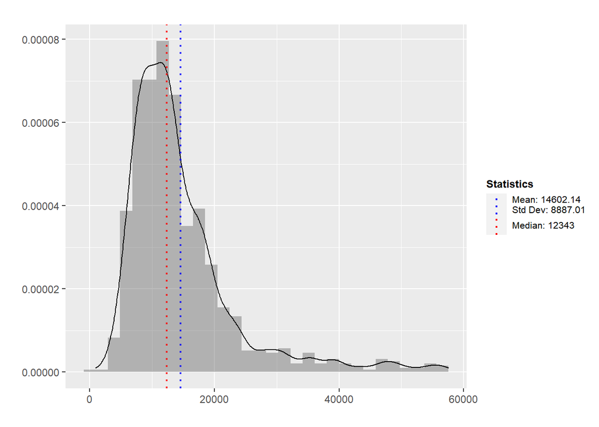

```r
plot_distribution(df_ipeds_pop$tuitfee_grad_res)
```

## 3.1 Normal, right-skew, left-skew

The distributions of variables fall into a few general categories

- we will talk about normally distributed variables, right-skewed variables, and left-skewed variables

In order to explain these concepts, we will generate a normally distributed variable, a right-skewed variable, and a left-skewed variable

We can refer to variables in the data frame `df_generated_pop` using the following syntax:

- `data_frame_name$variable_name`
- e.g., `df_generated_pop$norm_dist`

Examine the variable `norm_dist` in the data frame `df_generated_pop`

```r
length(df_generated_pop$norm_dist) # length() = number of "elements" = number of observations
```

```
#> [1] 10000
```

```r
#mean
mean(df_generated_pop$norm_dist, na.rm = TRUE)
```

```
#> [1] 49.98631
```

**Normal distribution**

- a normal distribution is “bell shaped”; has symmetric “tails”

We generated a variable `df_generated_pop$norm_dist` that has a normal distribution and then plot the variable to visualize what a normal distribution looks

- Descriptive statistics about the variable `df_generated_pop$norm_dist`
  - It has a mean of 49.99
  - It has a standard deviation of 4.99
    - Standard deviation is a measure of how far away from the mean observations tend to be
    - we can interpet this standard deviation as follows: on average, observations are 4.99 away from the mean of 49.99

We can also visualize the variable `df_generated_pop$norm_dist`, as shown below. Note the following:

- symmetric, “bell” shape
- the mean is (nearly) identical to the median

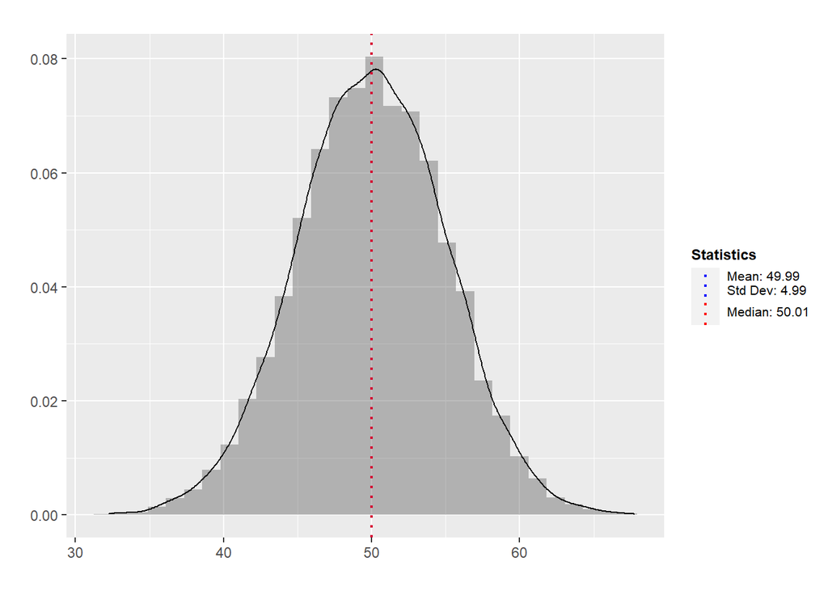

```r
plot_distribution(df_generated_pop$norm_dist)
```

**Skewed distribution**

- for a variable with a “skewed distribution” one “tail” is longer than the other
- “outliers” are often the cause of skewed distributions
  - outliers are observations that are much higher or much lower than most observations
- skewed distributions are either “left skewed” or “right skewed”

**Right skewed distributions**

- The right “tail” is longer than the left due to the presence of positive outliers, defined as observations with very high values compared to most observations
- so there are more positive outliers than you would expect in a bell (normal) shaped variable
- these positive outliers increase the value of the mean, such that the value of the mean is higher than the value of the median
  - mean > median
- real-world variables that tend to be right-skewed
  - income; enrollment size, city population

We generated the right-skewed variable `df_generated_pop$rskew_dist`

- This variable has the following descriptive statistics
  - mean equals 0.284
  - median equals 0.264
  - standard deviation equals 0.159
    - interpretation: on average, observations are 0.159 away from the mean of 0.284
- We can also visualize the right-skwed variable `df_generated_pop$rskew_dist`, as shown below. Note the following:
  - The right “tail” is longer than the left tail
  - the mean is larger than the median

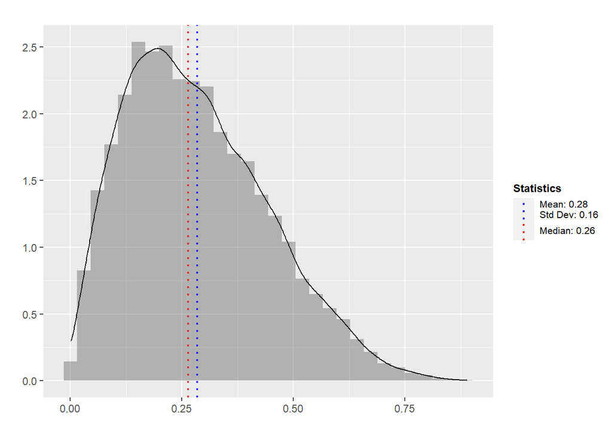

```r
plot_distribution(df_generated_pop$rskew_dist)
```

**Left skewed distributions**

- The left tail is longer than right tail, usually due to the presence of more negative outliers than would be expected in a bell shaped variable
  - where negative outliers are defined as observations with very low values (e.g., extreme negative values) compared to most observations
- these negative outliers decrease the value of the mean, such that the value of the mean is lower than the value of the median
- In social science research left-skewed variables are less common than right-skewed variables

Create and plot left-skewed variable

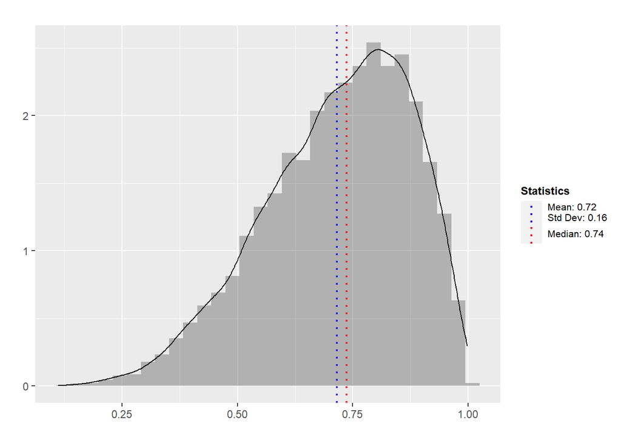

```r
plot_distribution(df_generated_pop$lskew_dist)
```

Having plotted generated variables that have normal, right skewed, and left skewed distributions, respectively, let’s plot the real-life variable `tuitfee_grad_res` from the data frame `df_ipeds_pop` (below). How would you diagnose the distribution of `tuitfee_grad_res`?

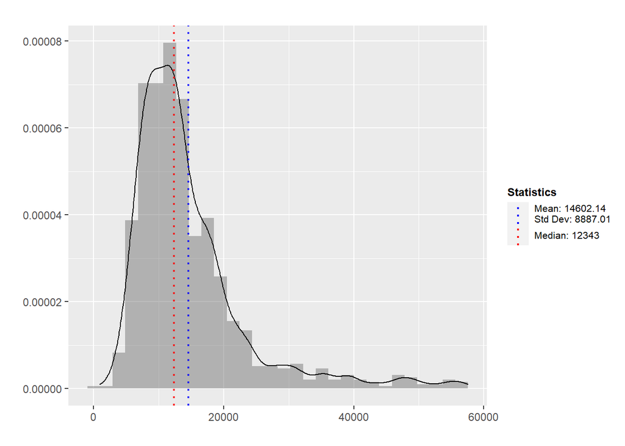

```r
plot_distribution(df_ipeds_pop$tuitfee_grad_res)
```

How would you diagnose the distribution of `tuitfee_grad_res`?

- right tail longer than the left
- mean of 14602 is larger than the median of 12343
- so this is a right skewed variable

## 3.2 Properties of the normal distribution

The normal distribution – symmetric, bell-shaped, mean equal to the median - has very useful properties that make it the basis of inferential statistics

- if we can reasonably assume a variable has a normal distribution, then we know a lot about that variable

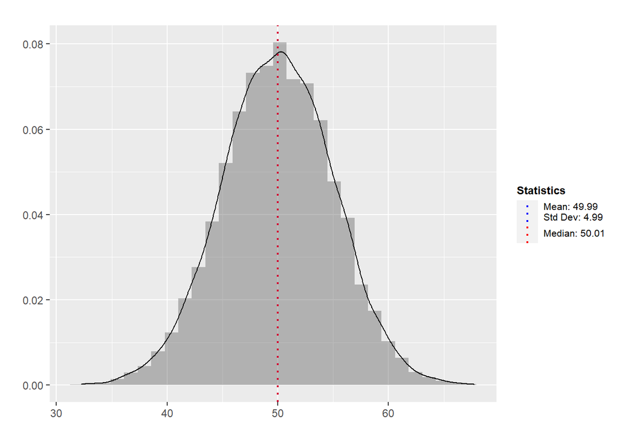

```r
plot_distribution(df_generated_pop$norm_dist)
```

### 3.2.1 Normal distribution and “the empirical rule”

Recall our primary measure of dispersion, standard deviation, which measures how far away individual observations tend to be from the mean.

- Here, for some variable $x$, I’ll give the formula for sample standard deviation, $\hat\sigma_x$, as opposed to the formula for population standard deviation, $\sigma_x$
  - sometimes people will also refer to sample standard deviation of $x$ as $s_x$
- $\hat\sigma_x = \sqrt{\frac{\sum_{i=1}^n (x_i - \overline{x})^2}{n-1}}$

**The empirical rule** states that if variable has an approximately normal distribution (i.e., approximately “bell shaped”) then:

- About 68% of obs fall within one std. dev of mean
  - i.e., between $x - \hat{\sigma{x}}$ and $x + \hat{\sigma{x}}$
- About 95% of obs fall within two std. dev of mean
  - i.e., between $x - 2\hat\sigma_x$ and $x + 2\hat\sigma_x$
- About 99% of obs fall within three std. dev of mean
  - i.e., between $x - 3\hat\sigma_x$ and $x + 3\hat\sigma_x$

Why is the empirical rule so important for inferential statistics?

- basically, if a variable has an approximately normal distribution, then we know how likely it would be to observe a variable that is a certain number of standard deviations away from the mean
- for example:
  - only about 2.5% of observations have a value higher than two standard deviations or more from the mean;
  - the variable `norm_dist` has a mean of about `50` and a standard deviation of about `5`, so the value of `40` would be about two standard deviations below the mean. the empirical rule tells us that only about 2.5% of observations would have a value less than `40`
- you might say, but most real-life variables are unlikely to have a normal distribution
  - True! But the “sampling distribution” – discussed below – which is the basis for all inferential statistics/hypothesis testing, **always** has a normal distribution so long as our sample size is large enough

### 3.2.2 Z-scores

The “z-score” of an observation is the number of standard deviations away from the mean

- can define a z-score in terms of a population or a sample from that population; we’ll introduce z-score in the context of sample data

z-score formula

- where $x$ is some variable of interest; subscript $i$ refers to observations
- $z_i = (x_i - \bar{x})/(\hat{\sigma}_x)$
- in words:
  - z score for observation $i$ equals the difference between the observation $x_i$ and the mean $\bar{x}$ divided by the standard deviation $\hat{\sigma}_x$
- Intuition behing z-score
  - it’s just the difference between an observation value and the mean value, scaled in terms of standard deviations
  - that’s why we say that the z-score represents the number of standard deviations away from the mean

Calculating z-score for the variable `norm_dist` from data frame `df_generated_pop`

```r
# components of z-score
mean(df_generated_pop$norm_dist, na.rm = TRUE)
```

```
#> [1] 49.98631
```

```r
sd(df_generated_pop$norm_dist, na.rm = TRUE)
```

```
#> [1] 4.991961
```

```r
#create new variable z_norm_dist
df_generated_pop <- df_generated_pop %>% mutate(
  z_norm_dist = (norm_dist - mean(norm_dist, na.rm = TRUE))/sd(norm_dist, na.rm = TRUE)
)

#list a few observations
df_generated_pop %>% select(norm_dist,z_norm_dist)
```

```
#> # A tibble: 10,000 x 2
#>    norm_dist z_norm_dist
#>        <dbl>       <dbl>
#>  1      43.1     -1.38
#>  2      50.2      0.0411
#>  3      46.2     -0.762
#>  4      51.1      0.215
#>  5      57.1      1.43
#>  6      53.7      0.748
#>  7      53.5      0.704
#>  8      48.9     -0.227
#>  9      51.0      0.200
#> 10      56.0      1.21
#> # ... with 9,990 more rows
```

```r
# mean of z-score variable
round(mean(df_generated_pop$z_norm_dist, na.rm = TRUE), digits = 4)
```

```
#> [1] 0
```

Plot the new z-score variable, which has:

- mean of about `0`
- standard deviation of about `1`

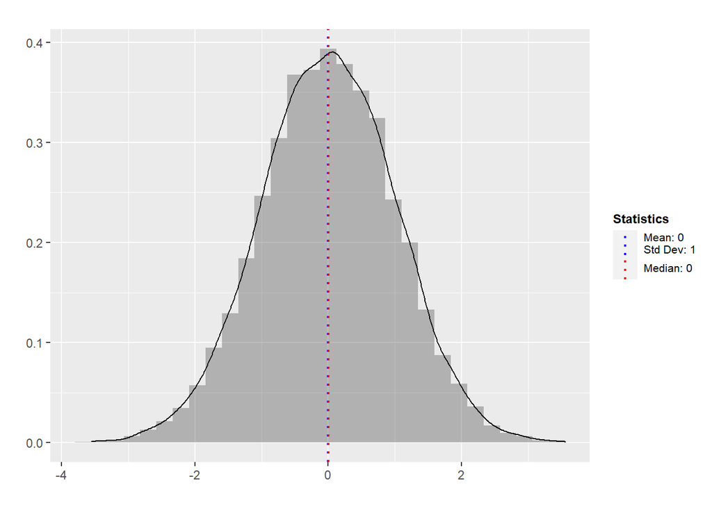

```r
plot_distribution(df_generated_pop$z_norm_dist)
```

Recall empirical rule for normally distributed variables

- About 68% of obs fall within one std. dev of mean
  - i.e., between $x - z$ and $x + z$
- About 95% of obs fall within two std. dev of mean
  - i.e., between $x - 2z$ and $x + 2z$
- About 99% of obs fall within three std. dev of mean
  - i.e., between $x - 3z$ and $x + 3z$

Delete variable `z_norm_dist`

```r
df_generated_pop$z_norm_dist <- NULL
```

## 3.3 Standard normal distribution

Definition:

- a bell-shaped (i.e., normal) distribution that has a mean of `0` and a standard deviation of `1`

Above, we created a variable `stdnorm_dist` in the data frame `df_generated_pop` that has a standard normal distribution. Let’s investigate and plot this variable:

```r
mean(df_generated_pop$stdnorm_dist, na.rm = TRUE)
```

```
#> [1] -0.002737966
```

```r
sd(df_generated_pop$stdnorm_dist, na.rm = TRUE)
```

```
#> [1] 0.9983922
```

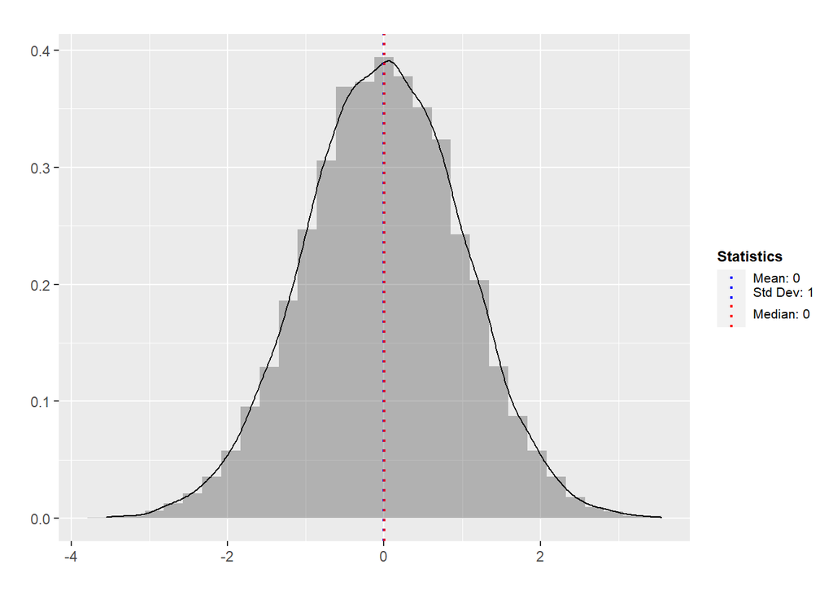

```r
plot_distribution(df_generated_pop$stdnorm_dist)
```

Commentary about standard normal distribution:

- The value of each observation is already in terms of z-scores
- That is, the value of each observation shows how many standard deviations it is from the mean
- Question: if the variable has a standard normal distribution, would it be likely to see an observation with a value of 3?
  - No. because a value of 3 would mean that the observation is three standard deviations greater than the mean. we know that for any variable with a normal distribution, less than 1% of observations have a value that is three standard deviations greater than the mean.

Question: If we have a variable with a roughly normal distribution (i.e., symmetrical), how could we transform it into a variable with a standard normal distribution (i.e., symmetrical with mean=0 and std deviation=1)?

- Answer: create new variable that is the z-score associated with each value
- This is exactly, what we did above (shown again here)

```r
# create variable that has a standard normal distribution from a variable that has a normal distribution
df_generated_pop %>% mutate(
  z_norm_dist = (norm_dist - mean(norm_dist, na.rm = TRUE))/sd(norm_dist, na.rm = TRUE)
)
```

```
#> # A tibble: 10,000 x 5
#>    norm_dist rskew_dist lskew_dist stdnorm_dist z_norm_dist
#>        <dbl>      <dbl>      <dbl>        <dbl>       <dbl>
#>  1      43.1     0.0827      0.917      -1.39       -1.38
#>  2      50.2     0.294       0.706       0.0383      0.0411
#>  3      46.2     0.156       0.844      -0.763      -0.762
#>  4      51.1     0.331       0.669       0.212       0.215
#>  5      57.1     0.651       0.349       1.43        1.43
#>  6      53.7     0.460       0.540       0.744       0.748
#>  7      53.5     0.448       0.552       0.700       0.704
#>  8      48.9     0.242       0.758      -0.229      -0.227
#>  9      51.0     0.327       0.673       0.197       0.200
#> 10      56.0     0.588       0.412       1.21        1.21
#> # ... with 9,990 more rows
```

# 4 Sampling distribution

The “sampling distribution” is the fundamental concept of inferential statistics

Briefly, recall the goal of inferential statistics:

- We want to make statements about population parameters, for example the population mean of some variable $x$, $\mu_x$
  - But we usually cannot obtain data on the entire population
- Therefore, we collect a representative (random) sample from the population
- We calculate “estimates” based on this sample data. These estimates are our best guess abut the value of population parameters
- For example, the sample mean $\bar{x}$ is our best guess of the population mean $\mu_x$

Usually, we collect a single sample from the population. How do we know if the sample we collected is representative of the underlying population we want to make statements about?

- This is a problem that statisticians have thought a lot about

For example, for our variable `norm_dist` from the data frame `df_generated_pop`, we randomly draw `30` observations from a population of `10,000` observations

```r
set.seed(321)
norm_dist_s1 <- sample(x = df_generated_pop$norm_dist, size = 30)

mean(df_generated_pop$norm_dist)
```

```
#> [1] 49.98631
```

```r
mean(norm_dist_s1) # mean of our sample
```

```
#> [1] 50.19565
```

But, what if we had obtained a different random sample?

```r
set.seed(123)
norm_dist_s1 <- sample(x = df_generated_pop$norm_dist, size = 30)

mean(df_generated_pop$norm_dist)
```

```
#> [1] 49.98631
```

```r
mean(norm_dist_s1) # mean of our sample
```

```
#> [1] 49.22062
```

```r
# remove object norm_dist_s1
rm(norm_dist_s1)
```

So we can see that the sample mean, $\bar{x}$, changes from sample to sample

Imagine if we take 1,000 random samples of size `n` (e.g., `30`) from a population

- for each random sample, we calculate the sample mean, and record the value of the sample mean
- we would have 1,000 observations, where each observation is the value of a sample mean
- If we plotted these 1,000 observations, it would give us a distribution of sample means
- More specifically, this would give us the “sampling distribution” of the sample mean

**Sampling distribution (of the sample mean)**

- The sampling distribution of the sample mean is a relative frequency distribution where each observation is the sample mean of a single random sample from a population
- The sampling distribution shows how the value of the sample mean varies from sample to sample

**Excellent website for understanding how the sampling distribution works**

- This very useful website does interactive simulations that show how the sampling distribution works [LINK](https://onlinestatbook.com/stat_sim/sampling_dist/index.html)
  - **Please** spend 5 minutes playing around with this website; this is really the most important concept in statistics

The sampling distribution of any statistic

- So far, we have discussed the sampling distribution of the sample mean, but a sampling distribution can be created for any sample statistic (e.g., median, min, max, regression coefficient)
- Once we get to the unit on regression, we’ll be thinking about the sampling distribution of a regression coefficient. But the underlying concepts will be exactly the same as the sampling distribution of the sample mean

## 4.1 Plot sampling distribution

**Plotting a single random sample and a sampling distribution**

- We are pretending our two data frames `df_generated_pop` and `df_ipeds_pop` contain all observations in the population
- For each of these datasets we will create a version that is a single random sample
- We will plot this single random sample
- Then we will take a large number of random samples, calculate the sample mean for each, and plot these sample means to create the sampling distribution

Plot the variable `norm_dist` from the sample dataset

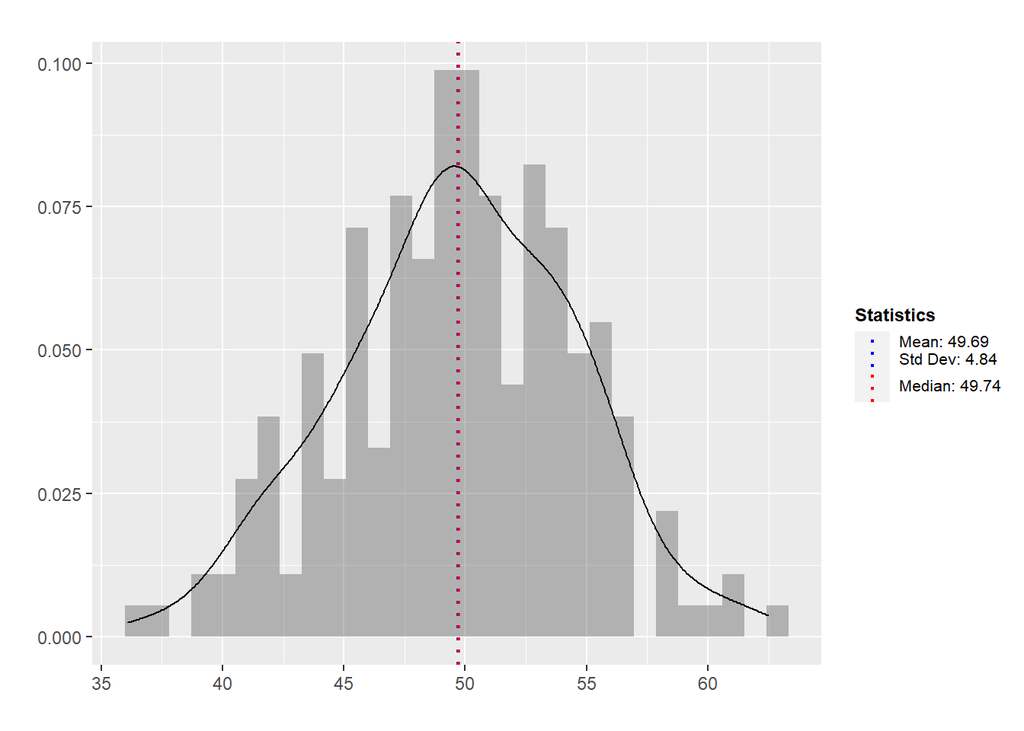

```r
plot_distribution(df_generated_sample$norm_dist)
```

Plot the variable `tuitfee_grad_res` from the sample IPEDS dataset

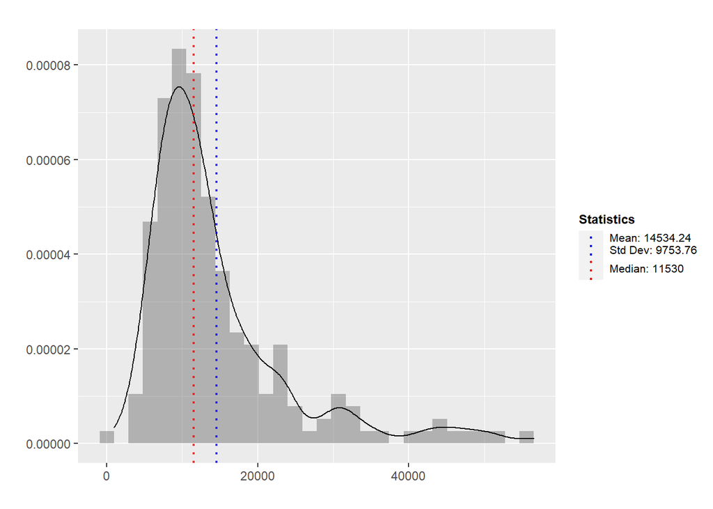

```r
plot_distribution(df_ipeds_sample$tuitfee_grad_res)
```

Plot the sampling distribution of of the sample mean for the normally distributed variable `norm_dist`

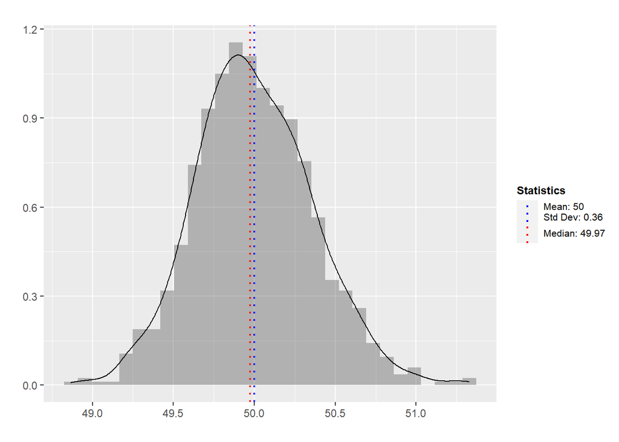

```r
plot_distribution(get_sampling_distribution(df_generated_pop$norm_dist))
```

Plot the sampling distribution of of the sample mean for the right-skewed variable `rskew_dist`

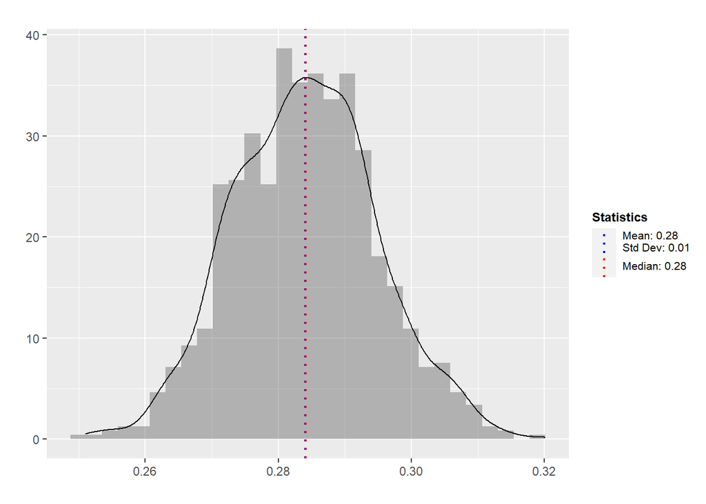

```r
plot_distribution(get_sampling_distribution(df_generated_pop$rskew_dist))
```

Create visualization that stacks three plots on top of one another: 1= population distribution; 2 = distribution of a single random sample; 3 = sampling distribution

- do this for the normally distributed variable `norm_dist`

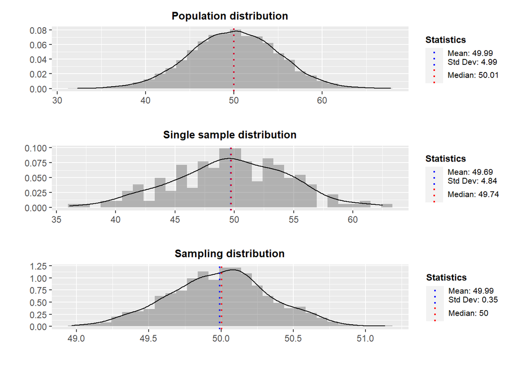

```r
plot_distribution(df_generated_pop$norm_dist, plot_title = 'Population distribution') +
  plot_distribution(df_generated_sample$norm_dist, plot_title = 'Single sample distribution') +
  plot_distribution(get_sampling_distribution(df_generated_pop$norm_dist),
                    plot_title = 'Sampling distribution') +
  plot_layout(ncol = 1)
```

Create visualization that stacks three plots on top of one another: 1= population distribution; 2 = distribution of a single random sample; 3 = sampling distribution

- do this for the right-skewed variable `rskew_dist`
- Notice that even though the underlying population is right skewed and the sample is right-skewed, the sampling distribution has a normal distribution

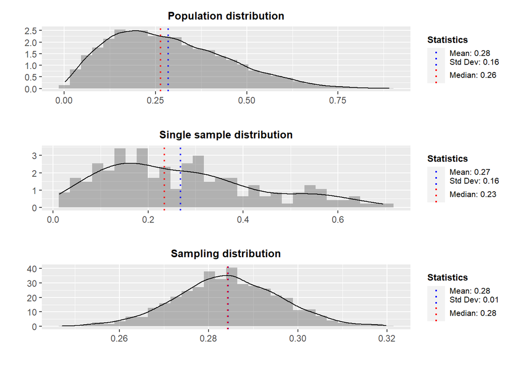

```r
plot_distribution(df_generated_pop$rskew_dist, plot_title = 'Population distribution') +
  plot_distribution(df_generated_sample$rskew_dist, plot_title = 'Single sample distribution') +
  plot_distribution(get_sampling_distribution(df_generated_pop$rskew_dist),
                    plot_title = 'Sampling distribution') +
  plot_layout(ncol = 1)
```

Create visualization that stacks three plots on top of one another: 1= population distribution; 2 = distribution of a single random sample; 3 = sampling distribution

- do this for the right-skewed variable `tuitfee_grad_res` from IPEDS
- Notice that even though the underlying population is right skewed and the sample is right-skewed, the sampling distribution has a normal distribution

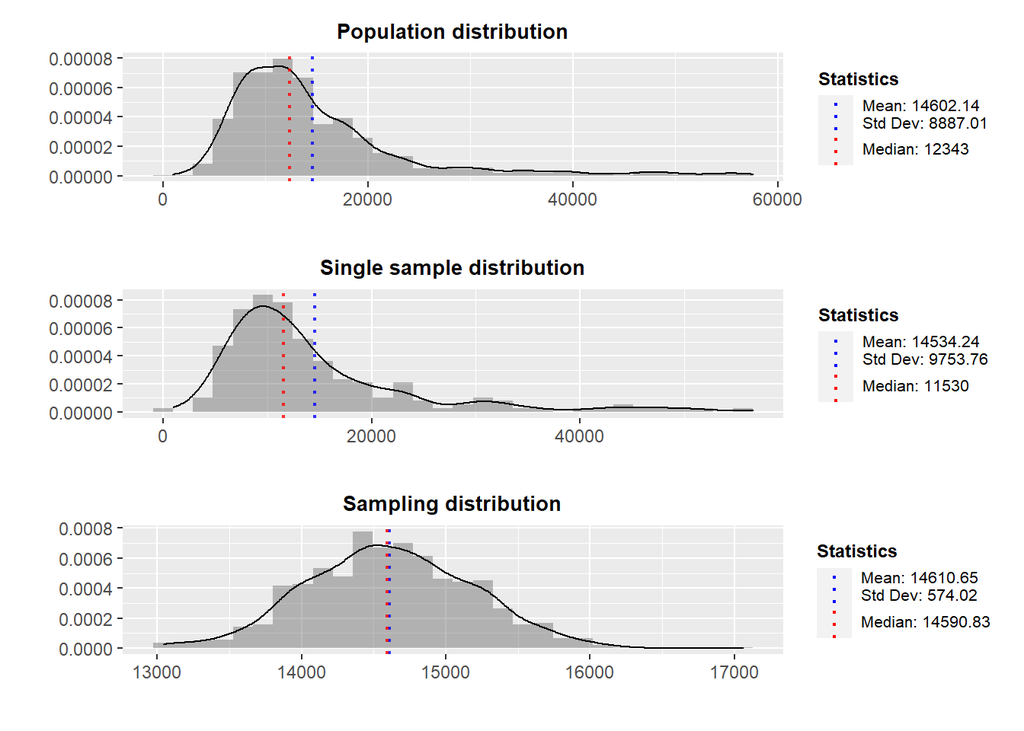

```r
plot_distribution(df_ipeds_pop$tuitfee_grad_res, plot_title = 'Population distribution') +
  plot_distribution(df_ipeds_sample$tuitfee_grad_res, plot_title = 'Single sample distribution') +
  plot_distribution(get_sampling_distribution(df_ipeds_pop$tuitfee_grad_res),
                    plot_title = 'Sampling distribution') +
  plot_layout(ncol = 1)
```

## 4.2 Central limit theorem

**Central limit theorem**

- For random sampling with a large sample size, $n$, the sampling distribution of the sample mean is approximately normally distributed
- In other words, no matter what the distribution of the variable, the sampling distribution will have a normal distribution

What counts as a “large” sample size?

- some say `n=30` or more

Why is central limit theorem important?

- We conducting hypothesis tests about a population parameter (e.g., about a population mean, about a population regression coefficient), based on the sampling distribution of the relevant sample statistic
- even if the underlying variable of interest has a skewed population, the sampling distribution of the sample statistic (e.g., sample mean) will have a normal distribution
- if the sampling distribution has a normal distribution, then we know the percent of observations that are a certain number of standard deviations from the mean

Show central limit theorem using interactive simulation

- [LINK](https://onlinestatbook.com/stat_sim/sampling_dist/index.html)

Show central limit theorem using a very skewed variable: non-resident, grad school cost of attendance

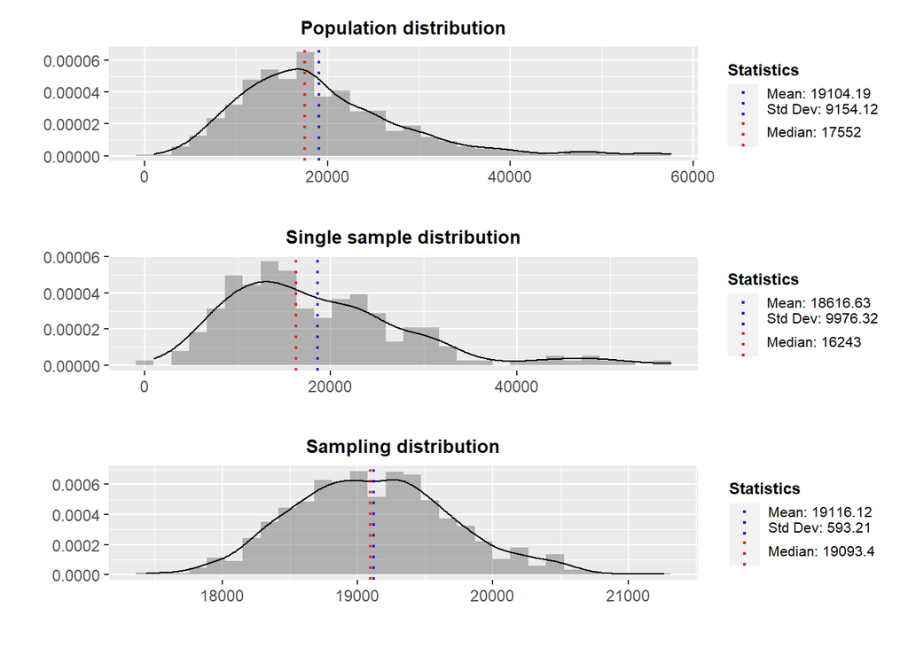

```r
plot_distribution(df_ipeds_pop$tuitfee_grad_nres, plot_title = 'Population distribution') +
  plot_distribution(df_ipeds_sample$tuitfee_grad_nres, plot_title = 'Single sample distribution') +
  plot_distribution(get_sampling_distribution(df_ipeds_pop$tuitfee_grad_nres),
                    plot_title = 'Sampling distribution') +
  plot_layout(ncol = 1)
```

## 4.3 Standard error

Sample standard deviation, of some variable $Y$

- Sample standard deviation, $\hat{\sigma}_Y$, is the average distance between a random observation and the sample mean $\bar{Y}$
- $\hat{\sigma}_Y = \sqrt{\frac{\sum_{i=1}^n (Y_i - \overline{Y})^2}{n-1}}$$

Sample standard error, of the sample mean, $\bar{Y}$

- Sample standard error, $\hat{\sigma}_{\bar{Y}}$, is based on the sampling distribution of the sample mean $\bar{Y}$
- Sample standard error, $\hat{\sigma}_{\bar{Y}}$, is the average distance between one random sample mean, $\bar{Y}$ and the mean of the sample means, $\bar{Y}_{\bar{Y}}$
  - note: assuming random sampling and a sufficiently large sample size, the mean of sample means, $\bar{Y}_{\bar{Y}}$, is equal to the population mean, $\mu_{Y}$
- In other words, Sample standard error, $\hat{\sigma}_{\bar{Y}}$, is the standard deviation of the sampling distribution
- Mathematically
  - $\hat{\sigma}_{\bar{Y}} = \hat{\sigma}_{Y}/\sqrt{n}$
  - equals sample standard deviation divided by the square root of sample size

Why is standard error so important?

- Example: percent of people who will vote for Obama in 2012 election (I wrote these bullets a long time ago…)
- Standard error tells us how much statistics derived from a sample are likely to diverge from population parameters
- Sample mean, $\bar{Y}$, is best estimate of the population mean, $\mu_Y$,, the percent of people in the population who will vote for Obama
- Standard error provides an indication of how far away each sample mean is likely to be from the population mean
- Supporse: – Standard error=10%: On average, the sample mean from each poll is likely to be 10% away from population mean – Standard error=2%: On average, the sample mean from each poll is likely to be 2% away from population mean

Do we want standard error to be large or small? Why?

- We want standard error to be small, because small standard error means that our estimates – based on sample data – are likely to be closer to the value of the population parameter of interest
- so, small standard error means more “precise” estimates

How to make standard error smaller?

- $\hat{\sigma}_{\bar{Y}} = \hat{\sigma}_{Y}/\sqrt{n}$
- Standard error decreases as size of your sample increases
- If you have a large sample size, the sample mean from one random sample is likely to be close to population mean – And when sample means are close to close to population mean, then standard error is small
- Example: mean income in US, with sample size of 10 versus sample size of 2,000
- Show in interactive demonstration
  - [LINK](https://onlinestatbook.com/stat_sim/sampling_dist/index.html)

# 5 Hypothesis testing about a population mean

## 5.1 What and Why hypothesis testing

Quantitative research in social sciences often proceeds as follows:

- Develop a research question (which guides our research)
- Develop one (or more) testable hypothesis based on that research question
- Obtain data necessary to test the hypothesis
- Test the hypothesis by applying an appropriate statistical test to the data

Some examples of research questions co-authors and I have answered over the years:

- What is the relationship between state appropriations and nonresident enrollment at public universities (Jaquette & Curs, 2015)?
- What is the effect of nonresident enrollment growth on the number of resident students enrolled at public research universities (Curs & Jaquette, 2017)?
- What is the effect of participation in the Mexican American Studies on the probability of high school graduation for students in the Tucscon Unified School District (Cabrera, Milem, Jaquette, & Marx, 2014)?
- Are high schools with a higher percentage of white students more likely to receive recruiting visits from university admissions officer than high schools with a lower percentage of white students (Salazar, Jaquette, & Han, n.d.)?

For each of these journal articles, we answered the research question by developing a “testable hypothesis” and testing that hypothesis using some statistical test

Developing testable hypothesis is central to univariate statistical analysis (one variable), bivariate statistical analysis (two variables), and multivariate statistical analysis (3+ variables, usually a regression model)

Example hypotheses for univariate, bivariate, multivariate statistical analyses

- Univariate statistics (hypothesis tests about a single population mean)
  - Hypothesis: the average annual cost of attendance for graduate school (tuition + fees + living expenses) is $50,000
- Bivariate statistics [hypothesis tests about comparing two population means]
  - Hypothesis: the average annual cost of attendance for graduate school (tuition + fees + living expenses) at private universities is higher than public universities
  - Hypothesis: the average annual cost of attendance for graduate school (tuition + fees + living expenses) at universities in urban areas is higher than universities in suburban areas
- Multivariate statistics (usually a regression model with one dependent variable, one independent variable of interest, and one or more “control” variables)
  - where dependent variable (Y) = cost of attendance; independent variable of interest (X) = private or public university; control variable = level of urbanization
  - Hypothesis: cost of attendance for graduate school is higher at private universities than public universities, even after controlling for level of urbanization

Why learn how to do hypothesis testing about a single population mean when this class is supposed to be about regression (and hypothesis tests about regression models)?

- You must learn the general principles/concepts about using point-estimates from sample data to test hypotheses about population parameters
- The simplest practical application of these general principles/concepts is testing hypotheses about the value of a single population mean
- The concepts/steps for hypotheses tests about a single population mean are exactly the same as those for testing hypotheses about regression models

## 5.2 Overview of steps in hypothesis testing

These are the general steps in hypothesis testing:

1. **Hypothesis**
   - formally state your “null” and “alternative” hypothesis
2. **Assumptions**
   - state assumptions that are relied upon by the statistical test you are using to test your hypothesis
3. **Test statistic**
   - Using some appropriate statistical analysis, calculate the “test statistic” necessary to test your hypothesis
4. **p-value (means probability value)**
   - calculate the probability of observing a test statistic as large or larger as the one you calculated
5. **Alpha level/rejection region and conclusion**
   - decide on the “alpha level,” the p-value associated with rejection of the null hypothesis
   - compare the p-value you you observed to the alpha level and make a conclusion about your hypothesis test

In real research projects, do researchers always follow these exact steps? In this exact order?

- Yes, they follow these steps
- But researchers do not necessarily follow steps in this exact order
  - e.g., usually, you would decide on an “alpha level” (rejection region) prior to conducting the statistical analysis
- Often, researchers will not write out each step as formally as we will ask you all to do.
  - We ask you to write out each step to give you practice. Later in the quarter, you won’t have to write out each step

Example we will use to introduce steps in hypothesis testing

- The population mean cost of attendance (COA) for full-time (resident) graduate students, $\mu_Y$, is $28,000

How we will teach you the steps in hypothesis testing in this lecture

- First, Introduce individual steps in detail, so that you develop a deep, conceptual understanding of each step
  - But when thinking about an individual step in detail, it can be hard to remember its relationship to other steps and to hypothesis testing as a whole
- Second, we will do another pratical example, where we work through all steps more quickly
  - so you can get a better sense of the hypothesis testing process as a whole and the relationships between steps

## 5.3 Hypotheses

This section presents a more formal introduction to hypotheses, focusing on univariate statistical analyses rather than bivariate or multivariate

Recall that the goal of inferential statistics is to make statements about a population of interest based on data from a representative sample from the population.

- We make a hypotheses about a population parameter (e.g., population mean of variable $Y$ denotes $\mu_Y$)
- Knowing the true value of the population parameter would require having data on all observations in the population
- Usually, we do not have data on the entire population
- We use sample data to test hypotheses about the population

Definition

- In statistics, a **hypothesis** is a declarative statement about a population.

In univariate statistical analyses, we make a hypothesis about one population paramaeter (e.g., population mean $\mu_Y$) from one population of interest (e.g., all “research” universities and “master’s” universities, as defined by the Carnegie Classification)

```r
df_ipeds_pop %>% glimpse()
```

```
#> Rows: 991
#> Columns: 38
#> $ instnm            <chr> "Alabama A & M University", "University of Alabama at Birmingham", "Amridge University", "University of Alabama in Huntsville", "Alabama State University", "The University of Alabama", "Auburn University at Montgomery", "Auburn University", "Faulkner University", "Jackso…
#> $ unitid            <dbl> 100654, 100663, 100690, 100706, 100724, 100751, 100830, 100858, 101189, 101480, 101587, 101709, 101879, 102049, 102094, 102368, 102377, 102553, 102614, 102632, 102669, 104151, 104179, 104717, 105330, 105589, 106245, 106397, 106458, 106467, 106485, 106704, 107044, 107071,…
#> $ opeid6            <chr> "001002", "001052", "025034", "001055", "001005", "001051", "008310", "001009", "001003", "001020", "001024", "001004", "001016", "001036", "001057", "001047", "001050", "011462", "001063", "001065", "001061", "001081", "001083", "001074", "001082", "020653", "001101", "…
#> $ opeid             <chr> "00100200", "00105200", "02503400", "00105500", "00100500", "00105100", "00831000", "00100900", "00100300", "00102000", "00102400", "00100400", "00101600", "00103600", "00105700", "00104700", "00105000", "01146200", "00106300", "00106500", "00106100", "00108100", "001083…
#> $ control           <dbl+lbl> 1, 1, 2, 1, 1, 1, 1, 1, 2, 1, 1, 1, 1, 2, 1, 1, 2, 1, 1, 1, 2, 1, 1, 3, 1, 2, 1, 1, 1, 1, 1, 1, 2, 1, 2, 1, 2, 2, 2, 2, 2, 1, 3, 1, 1, 1, 1, 1, 1, 1, 1, 1, 1, 1, 1, 1, 1, 1, 1, 1, 1, 1, 1, 1, 2, 2, 2, 2, 2, 1, 2, 2, 2, 2, 2, 2, 2, 2, 2, 2, 2, 2, 2, 1, 2, 1, 2, 1, 2, …
#> $ c15basic          <dbl+lbl> 18, 15, 20, 16, 19, 16, 18, 16, 20, 18, 18, 19, 18, 18, 16, 18, 20, 18, 16, 19, 20, 15, 15, 17, 16, 20, 17, 15, 18, 18, 20, 18, 18, 19, 19, 19, 17, 17, 18, 15, 18, 18, 17, 18, 18, 18, 18, 18, 18, 17, 17, 18, 18, 18, 18, 18, 15, 15, 15, 15, 15, 15, 15, 15, 18, 18, 19,…
#> $ stabbr            <chr+lbl> "AL", "AL", "AL", "AL", "AL", "AL", "AL", "AL", "AL", "AL", "AL", "AL", "AL", "AL", "AL", "AL", "AL", "AK", "AK", "AK", "AK", "AZ", "AZ", "AZ", "AZ", "AZ", "AR", "AR", "AR", "AR", "AR", "AR", "AR", "AR", "AR", "AR", "CA", "CA", "CA", "CA", "CA", "CA", "CA", "CA", "CA…
#> $ city              <chr> "Normal", "Birmingham", "Montgomery", "Huntsville", "Montgomery", "Tuscaloosa", "Montgomery", "Auburn", "Montgomery", "Jacksonville", "Livingston", "Montevallo", "Florence", "Birmingham", "Mobile", "Troy", "Tuskegee", "Anchorage", "Fairbanks", "Juneau", "Anchorage", "Tem…
#> $ zip               <chr> "35762", "35294-0110", "36117-3553", "35899", "36104-0271", "35487-0100", "36117-3596", "36849", "36109-3390", "36265", "35470", "35115-6000", "35632-0001", "35229-2240", "36688-0002", "36082-0001", "36088-1920", "99508", "99775", "99801-8697", "99508", "85287", "85721-0…
#> $ locale            <dbl+lbl> 12, 12, 12, 12, 12, 12, 12, 13, 12, 23, 43, 21, 13, 21, 12, 33, 32, 11, 23, 33, 11, 12, 11, 11, 13, 13, 12, 13, 13, 33, 33, 13, 32, 32, 32, 33, 21, 21, 11, 12, 12, 23, 11, 11, 23, 12, 21, 13, 13, 11, 21, 21, 11, 11, 11, 11, 12, 23, 11, 11, 11, 11, 22, 13, 12, 11, 13,…
#> $ region            <dbl+lbl> 5, 5, 5, 5, 5, 5, 5, 5, 5, 5, 5, 5, 5, 5, 5, 5, 5, 8, 8, 8, 8, 6, 6, 6, 6, 6, 5, 5, 5, 5, 5, 5, 5, 5, 5, 5, 8, 8, 8, 8, 8, 8, 8, 8, 8, 8, 8, 8, 8, 8, 8, 8, 8, 8, 8, 8, 8, 8, 8, 8, 8, 8, 8, 8, 8, 8, 8, 8, 8, 8, 8, 8, 8, 8, 8, 8, 8, 8, 8, 8, 8, 8, 8, 8, 8, 8, 8, 8, 8, …
#> $ tuit_grad_res     <dbl> 10128, 8100, 11700, 10632, 7416, 10780, 7362, 9828, 10080, 9600, 6678, 10512, 6660, 17754, 7956, 7650, 19594, 11286, 10414, 11132, 11700, 11720, 11938, 10175, 10305, 21696, 5760, 7752, 4986, 5256, 6631, 5018, 13372, 5058, 14400, 5040, 17592, 11394, 12830, 52506, 19406, 7…
#> $ fee_grad_res      <dbl> 1414, 0, 1300, 826, 2740, 0, 766, 1676, 1450, 1000, 190, 1404, 540, 610, 200, 856, 3020, 1474, 1842, 1476, 410, 888, 1333, 899, 816, 590, 1834, 1089, 1436, 1481, 2496, 1521, 520, 1329, 0, 1542, 250, 0, 730, 2031, 150, 4201, 360, 1677, 1800, 1210, 1654, 2064, 1204, 847, 1…
```

[output cut: 25 more lines]

```r
mean(df_ipeds_pop$coa_grad_res, na.rm = TRUE)
```

```
#> [1] 30318.74
```

### 5.3.1 null and alternative hypothesis

When developing a hypothesis for quantitative research, we always specify a **null hypothesis ($H_0$)** AND an **alternative hypothesis ($H_a$)**

**Null hypothesis ($H_0$)**

- In univariate statistics, a null hypothesis ($H_0$) is a declarative statement that the population parameter has a specific value
- (in words) $H_0:$ the population mean cost of attendance for for full-time (resident) graduate students, $\mu_Y$, is $28,000
- (using symbols) $H_0: \mu_Y = \mu_{Y0} = \$28,000$
  - where $\mu_{Y0}$ refers to the parameter value associated with the null hypothesis
  - when testing a hypothesis about a single population mean, we can refer to $\mu_{Y0}$ as the “null population mean”

**Alternative hypothesis ($H_a$)**

- An alternative hypothesis ($H_a$) is a declarative statement that the population parameter falls in some alternative range of values as compared to the value declared by the null hypothesis
- There are two kinds of alternative hypotheses: two-sided; and one-sided
- for a given null hypothesis ($H_0$), there will always be one two-sided alternative hypothesis and two different one-sided hypotheses

Two-sided alternative hypothesis

- (in words) $H_a:$ the population mean mean cost of attendance for for full-time (resident) graduate students, $\mu_Y$, is not equal to $28,000
- (using symbols) $H_a: \mu_Y \ne \$28,000$

One-sided alternative hypothesis (mean is greater than $\$28,000$)

- (in words) $H_a:$ the population mean mean cost of attendance for for full-time (resident) graduate students, $\mu_Y$, is greater than $28,000
- (using symbols) $H_a: \mu_Y \gt \$28,000$

One-sided alternative hypothesis (mean is less than $\$28,000$)

- (in words) $H_a:$ the population mean mean cost of attendance for for full-time (resident) graduate students, $\mu_Y$, is less than $28,000
- (using symbols) $H_a: \mu_Y \lt \$28,000$

ISSUE - EQUATIONS NOT FORMATTING CORRECTLY, EVEN WHEN I CHANGE INDENTATION ASSOCIATED WITH BULLETS

**Example of null and alternative hypotheses for bivariate statistical analysis**

Research question:

- Is the population mean annual cost of attendance for graduate school at public universities ($\mu_{Y_{{pub}}}$) different from the population mean annual cost of attendance for graduate school at private universities ($\mu_{Y_{{priv}}}$)?

Null and alternative hypotheses

- null hypothesis ($H_0$)
  - (in words): $H_0:$ the population mean annual cost of attendance for graduate school at public universities ($\mu_{Y_{{pub}}}$) is the same as the population mean annual cost of attendance for graduate school at private universities ($\mu_{Y_{{priv}}}$)
  - (symbols): $H_0: \mu_{Y_{{pub}}} = \mu_{Y_{{priv}}}$
- Two-sided alternative hypothesis
  - (in words): $H_a:$ the population mean annual cost of attendance for graduate school at public universities ($\mu_{Y_{{pub}}}$) is different than the population mean annual cost of attendance for graduate school at private universities ($\mu_{Y_{{priv}}}$)
  - (symbols): $H_a: \mu_{Y_{{pub}}} \ne \mu_{Y_{{priv}}}$
- One-sided alternative hypothesis ($pub < priv$)
  - (in words): $H_a:$ the population mean annual cost of attendance for graduate school at public universities ($\mu_{Y_{{pub}}}$) is less than than the population mean annual cost of attendance for graduate school at private universities ($\mu_{Y_{{priv}}}$)
  - (symbols): $H_a: \mu_{Y_{{pub}}} \lt \mu_{Y_{{priv}}}$
  - note: this is the same as a one-sided hypothesis where we hypothesize $priv > pub$
- One-sided alternative hypothesis ($pub > priv $)
  - (in words): $H_a:$ the population mean annual cost of attendance for graduate school at public universities ($\mu_{Y_{{pub}}}$) is greater than than the population mean annual cost of attendance for graduate school at private universities ($\mu_{Y_{{priv}}}$)
  - (symbols): $H_a: \mu_{Y_{{pub}}} \gt \mu_{Y_{{priv}}}$
  - note: this is the same as a one-sided hypothesis where we hypothesize $priv < pub$

### 5.3.2 Two-sided or one-sided alternative hypotheses?

In real research projects, we are not usually testing a hypothesis about a single population mean (univariate analysis). Rather, we are usually comparing population means of two different groups (bivariate analysis) or we are examining the relationship between an independent variable and the dependent variable after controlling for other variables (multivariate regression analysis)

Prior to conducting analyses, we usually have an expectation/suspicion about the result

Should we specify two-sided or one-sided alternative hypothesis, $H_a$?

- For univariate and bivariate statistical analyses, researchers specify a two-sided alternative hypothesis more often than a one-sided alternative alternative hypothesis
  - often, researchers specify a two-sided alternative hypothesis even when they strongly believe one particular group has a larger population mean then the other
- For multivariate regression analyses, researchers **always** specify and test two-sided alternative hypotheses
  - even when they strongly believe the relationship between $X$ and $Y$ is positive; and even when they strongly believe the relationship between $X$ and $Y$ is positive
- Why this preference for two-sided alternative hypotheses in real research projects?
  - two-sided alternative hypotheses are more “conservative” than one-sided alternative hypotheses;
  - that is, if you specify a two-sided alternative hypothesis, $H_a$, and reject the null hypothesis, $H_0$, then it is necessarily true that we would have rejected then null hypothesis, $H_0$, had we specified a one-sided alternative hypothesis, $H_a$

Because *EDUC152* is a course about regression rather than univariate/bivariate statistics, we will *always* specify two-sided alternative hypotheses and ignore one-sided alternative hypotheses from here on out

- this will make learning hypothesis testing easier

## 5.4 Test statistic

restate null, $H_0$, and alternative (two-sided), $H_a$, hypothesis for our practical example

- $H_0$
  - (in words) $H_0:$ the population mean cost of attendance for for full-time (resident) graduate students, $\mu_Y$, is $28,000
  - (symbols) $H_0: \mu_Y = \mu_{Y0} = \$28,000$
- $H_a$
  - (in words) $H_a:$ the population mean mean cost of attendance for for full-time (resident) graduate students, $\mu_Y$, is not equal to $28,000
  - (symbols) $H_a: \mu_Y \ne \$28,000$

We must conduct a formal statistical test to decide whether we should reject the null hypothesis

- this is true for testing hypotheses about a population mean from a single population; testing hypotheses about whether two population means are equal; testing hypotheses about a regression coefficient, etc.
- **key to understanding hypothesis testing**: We conduct our test under the assumption that the null hypothesis, $H_0$, is true

Logic of the test statistic

- What the test statistic calculates
  - if the null hypothesis is true, how unlikely would it be to randomly draw the sample estimate (e.g., sample mean $\bar{Y}$) at least as far away from the null hypothesis value as the one we observed in our single random sample
  - e.g., "if the null hypothesis is true, there is a 1.5% chance of observing a sample mean at least as far away from the null hypothesis value ($\mu_{Y0} = \$28,000$) as the one we observed in our single random sample
- Logic of the test statistic
  - if – under the assumption that the null hypothesis is true – it would be very unlikely to observe the sample estimate we observed, then it is unlikely that the null hypothesis is true

**General formula for test statistic (for pretty much any kind of hypothesis test)**:

$$test\_statistic = \frac{sample\_estimate - value\_associated\_with\_H_0}{sample\_standard\_error}$$
**Formula for test statistic about a single population mean**

- in words:
  - test-statistic $t$ equals difference between the sample mean $\bar{Y}$ and the population mean associated with the null hypothesis $\mu_{Y0}$ divided by the sample standard error of the sample mean $\hat{\sigma}_{\bar{Y}}$
- equation:
  - $t = \frac{\bar{Y} - \mu_{Y0}}{\hat{\sigma}_{\bar{Y}}}$
- where:
  - $\hat{\sigma}_{Y}$ refers to sample standard deviation of variable $Y$
  - $n$ refers to sample size
  - sample standard error of the sample mean $= \hat{\sigma}_{\bar{Y}} = \frac{\hat{\sigma}_{Y}}{\sqrt{n}}$

**Calculating t-test statistic for our practical example**

$H_0: \mu_Y = \mu_{Y0} = \$28,000$ ; $H_a: \mu_Y \ne \$28,000$

Calculate components of t-test (using functions and by hand)

```r
# sample size
  length(df_ipeds_sample$coa_grad_res) # assuming no missing observations
```

```
#> [1] 200
```

```r
  df_ipeds_sample %>% summarize(n_non_miss = sum(!(is.na(coa_grad_res)))) # count only number of non-missing
```

```
#> # A tibble: 1 x 1
#>   n_non_miss
#>        <int>
#> 1        200
```

```r
# sample mean of coa_grad_res
  mean(df_ipeds_sample$coa_grad_res, na.rm = TRUE) # using function
```

```
#> [1] 30002.74
```

```r
# sample standard deviation of coa_grad_res
  sd(df_ipeds_sample$coa_grad_res, na.rm = TRUE)
```

```
#> [1] 11457.01
```

```r
# sample standard error of sample mean of coa_grad_res = std_dev/sqrt(n)
  sd(df_ipeds_sample$coa_grad_res, na.rm = TRUE)/sqrt(length(df_ipeds_sample$coa_grad_res))
```

```
#> [1] 810.1332
```

Components of t-test:

- sample size, $n$ = 200
- sample mean, $\bar{Y}$ = 30002.745
- Population mean associated with $H_0$, $\mu_{Y0} = \$28,000$
- sample standard deviation, $\hat{\sigma}_{Y}$ = 11457.014
- sample standard error of the sample mean, $\hat{\sigma}_{\bar{Y}}$ = 810.1332

Calculating t-test

$$t = \frac{\bar{Y} - \mu_{Y0}}{\hat{\sigma}_{\bar{Y}}} = \frac{30002.74 - 28000}{810.1332} = 2.4721$$

**`t.test()` function**

- what `t.test()` does
  - “Performs one and two sample t-tests on vectors of data”
  - we use one sample t-test to test hypothesis about single population mean
  - later, we will use two-samle t-test to test hypotheses about whether two population means are equal
- syntax:
  - `t.test(x, y = NULL, alternative = c("two.sided", "less", "greater"), mu = 0, paired = FALSE, var.equal = FALSE, conf.level = 0.95, ...)`
- selected arguments
  - `x`: vector (variable) you want to calculate t-test for
  - `alternative`: whether you want two-sided or one-sided alternative hypothesis (default is `two.sided`)
  - `mu`: value associated with null hypothesis (default is `0`)

Calculating t-test value (using function and by hand)

```r
# t-statistic = (sample_mean - mu_H_0)/(sample std err)

# using function
#?t.test # to see help file for function
t.test(x = df_ipeds_sample$coa_grad_res, mu = 28000)
```

```
#>
#>  One Sample t-test
#>
#> data:  df_ipeds_sample$coa_grad_res
#> t = 2.4721, df = 199, p-value = 0.01427
#> alternative hypothesis: true mean is not equal to 28000
#> 95 percent confidence interval:
#>  28405.20 31600.29
#> sample estimates:
#> mean of x
#>  30002.74
```

```r
# by hand
(mean(df_ipeds_sample$coa_grad_res, na.rm = TRUE) - 28000)/(sd(df_ipeds_sample$coa_grad_res, na.rm = TRUE)/sqrt(length(df_ipeds_sample$coa_grad_res)))
```

```
#> [1] 2.472118
```

### 5.4.1 conceptual understanding of test statistic (**MOST IMPORTANT!**)

The test statistic refers to a **sampling distribution** not the distribution of your single sample

- in particular, the test statistic refers to the sampling distribution under the assumption that the null hypothesis is true, $H_0: \mu_Y = \mu_{Y0}$

Recall core ideas of sampling distribution (we will refer to sampling distribution of sample mean, $\bar{Y}$)

- The sampling distribution of the sampling mean is a distribution where each observation is a sample mean, $\bar{Y}$, from one random sample taken from the population
- The sampling distribution shows how the value of the sample mean varies from sample to sample
- Standard error (i.e., the standard deviation of the sampling distribution), $\hat{\sigma}_{\bar{Y}}$ is the average distance between one random sample mean, $\bar{Y}$, and the mean of sample means $\bar{Y}_{\bar{Y}}$
  - (Note: we refer to sample standard error of the sample mean $\hat{\sigma}_{\bar{Y}} = \frac{\hat{\sigma}_{Y}}{\sqrt{n}}$, which can be calculated from sample data, rather than population standard error of the sample mean $\sigma_{\bar{Y}}$, which is a population parameter that is only known if we have data on the entire population)
- Drawing from the central limit theorem, we know that sampling distributions will always be normally distributed so long as sample size is not small
- Therefore, sampling distributions follow the empirical rule:
  - 68% of observations within one standard error
  - 95% of observations wtithin two standard erros
  - 99% of observations within three standard errors

Here we visually stack the following for the variable `coa_grad_res`:

- the population distribution; distribution from a single random sample; and sampling distribution of sample mean

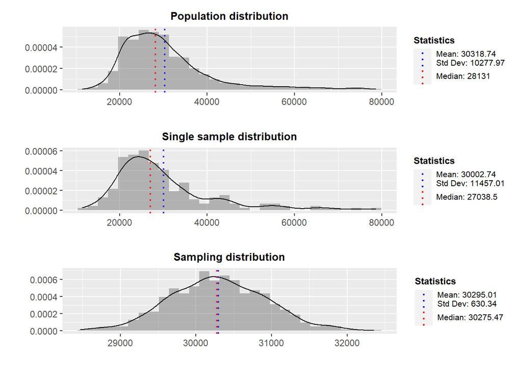

```r
plot_distribution(df_ipeds_pop$coa_grad_res, plot_title = 'Population distribution') +
  plot_distribution(df_ipeds_sample$coa_grad_res, plot_title = 'Single sample distribution') +
  plot_distribution(get_sampling_distribution(df_ipeds_pop$coa_grad_res), plot_title = 'Sampling distribution') +
  plot_layout(ncol = 1)
```

**Usually we cannot know the sampling distribution because we do not have data on the entire population; we only have data on our single random sample**

However, hypothesis testing is not based on the true sampling distribution of the sample mean. It is based on the sampling distribution under the assumption that the null hypothesis is correct

- Thanks to the central limit theorem, we have a pretty good idea of the sampling distribution assuming $H_0$ is true, even when we only have a single random sample!

Here we visually stack the following for the variable `coa_grad_res`:

- the population distribution; distribution from a single random sample; and sampling distribution of assuming that $H_0$ is true

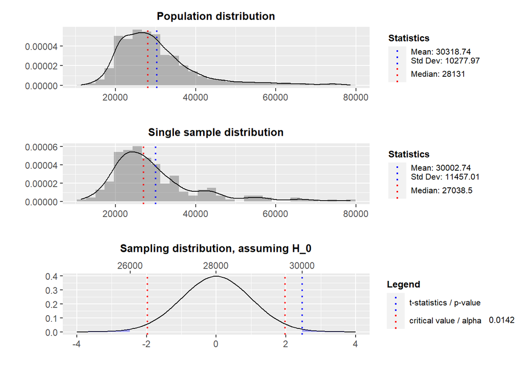

```r
plot_distribution(df_ipeds_pop$coa_grad_res, plot_title = 'Population distribution') +
  plot_distribution(df_ipeds_sample$coa_grad_res, plot_title = 'Single sample distribution') +
  plot_t_distribution(df_ipeds_sample$coa_grad_res, mu = 28000,shade_rejection = F, shade_pval = T, plot_title = 'Sampling distribution, assuming H_0') +
  plot_layout(ncol = 1)
```

The t-test statistic is the distance between the hypothesized $H_0$ value and the observed sample estimate value $\bar{Y}$ scaled in terms of standard errors

- e.g., it would be unlikely to observe a t-value of greater than `2` or a t-value less than `-2` because we know (from empirical rule and central limit theorem) that 95% of observations fall within two standard deviations of the mean for a normally distributed variable

## 5.5 p-value

“p-value” refers to the probability-value associated with the t-value from your test statistic

Definition

- Under the assumption that $H_0$ is true, the **p-value** is the probability of observing a sample estimate (and its associated test-statistic) that is at least as far away from the null hypothesis value $\mu_{Y0}$ as the one we observed

Calculating p-value For a two-sided alternative hypothesis ($H_a: \mu_Y \ne \mu_{Y0}$)

- let $t$ be the value of your t-test
- let $p$ by the p-value associated with $t$
- let $Pr(obs>t)$ is the probability of an observation having a higher value of $t$ than the one you observed
- $p = Pr(obs > t) + Pr(obs< -t)$
- Because the sampling distribution is symmetric (because it is normally distributed):
  - $Pr(obs >t) = Pr(obs < - t)$
- therefore, for a two-sided alternative hypothesis
  - $p = 2*Pr(obs > t)$

Let’s calculate and visualize p-value for a couple different hypothesized values of the population mean $\mu_{Y0}$ for the variable `coa_grad_res` (full-time, resident grad school cost of attendance) from the data frame `df_ipeds_sample`

$H_0: \mu_Y = \mu_{Y0} = \$29,000$ and $H_a: \mu_Y \ne \$29,000$

- Sample mean, ${Y} = $ 30002.745
- $t =$ 1.24
- p-value $= Pr(obs > t) + Pr(obs< -t) =$ 0.217
  - $Pr(obs>t)=$ 0.1086
  - $Pr(obs<-t)=$ 0.1086
- below code chunk runs t-test and plots t-value against sampling distribution assuming $H_0$ is true

```r
mean(x = df_ipeds_sample$coa_grad_res)
```

```
#> [1] 30002.74
```

```r
t.test(x = df_ipeds_sample$coa_grad_res, mu = 29000)
```

```
#>
#>  One Sample t-test
#>
#> data:  df_ipeds_sample$coa_grad_res
#> t = 1.2378, df = 199, p-value = 0.2173
#> alternative hypothesis: true mean is not equal to 29000
#> 95 percent confidence interval:
#>  28405.20 31600.29
#> sample estimates:
#> mean of x
#>  30002.74
```

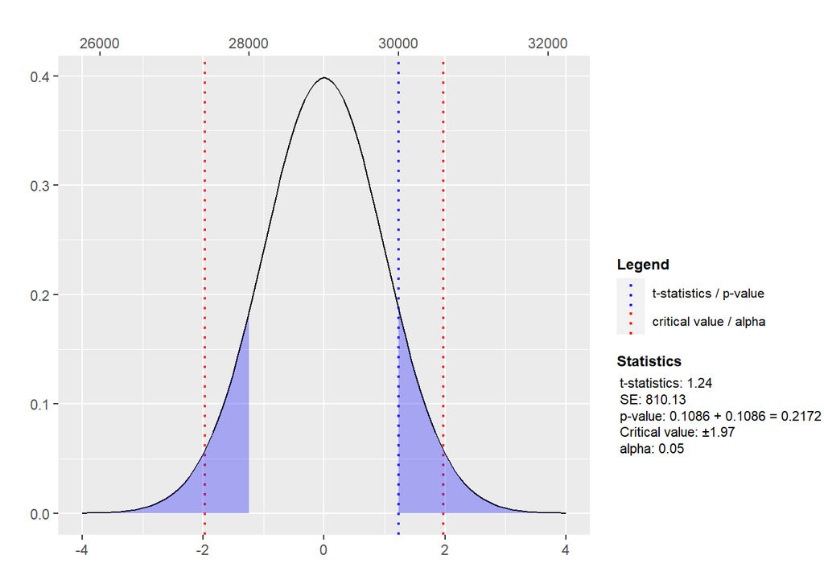

```r
plot_t_distribution(df_ipeds_sample$coa_grad_res, mu = 29000,shade_rejection = F, shade_pval = T)
```

$H_0: \mu_Y = \mu_{Y0} = \$28,000$ and $H_a: \mu_Y \ne \$28,000$

- Sample mean, ${Y} = $ 30002.745
- $t =$ 2.47
- p-value $= Pr(obs > t) + Pr(obs< -t) =$ 0.014
  - $Pr(obs>t)=$ 0.0071
  - $Pr(obs<-t)=$ 0.0071
- below code chunk runs t-test and plots t-value against sampling distribution assuming $H_0$ is true

```r
mean(x = df_ipeds_sample$coa_grad_res)
```

```
#> [1] 30002.74
```

```r
t.test(x = df_ipeds_sample$coa_grad_res, mu = 28000)
```

```
#>
#>  One Sample t-test
#>
#> data:  df_ipeds_sample$coa_grad_res
#> t = 2.4721, df = 199, p-value = 0.01427
#> alternative hypothesis: true mean is not equal to 28000
#> 95 percent confidence interval:
#>  28405.20 31600.29
#> sample estimates:
#> mean of x
#>  30002.74
```

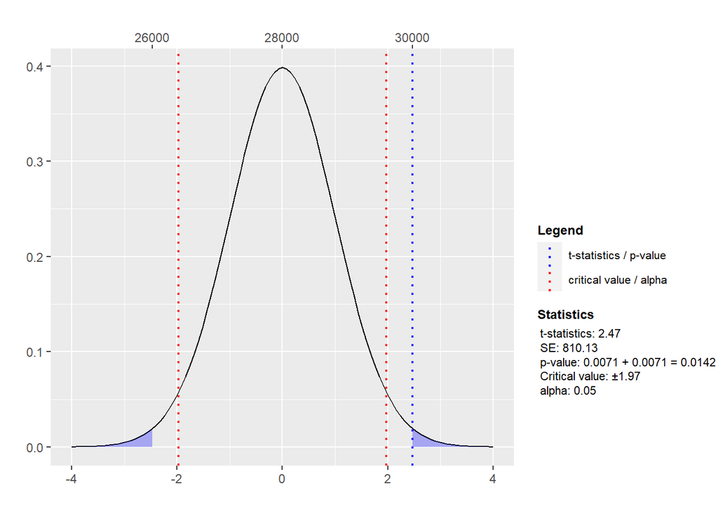

```r
plot_t_distribution(df_ipeds_sample$coa_grad_res, mu = 28000,shade_rejection = F, shade_pval = T)
```

$H_0: \mu_Y = \mu_{Y0} = \$31,500$ and $H_a: \mu_Y \ne \$31,500$

- Sample mean, $\bar{Y} =$ 30002.745
- $t =$ -1.85
- p-value $= Pr(obs > t) + Pr(obs< -t) =$ 0.066
  - $Pr(obs>t)=$ 0.033
  - $Pr(obs<-t)=$ 0.033
- below code chunk runs t-test and plots t-value against sampling distribution assuming $H_0$ is true

```r
mean(x = df_ipeds_sample$coa_grad_res)
```

```
#> [1] 30002.74
```

```r
t.test(x = df_ipeds_sample$coa_grad_res, mu = 31500)
```

```
#>
#>  One Sample t-test
#>
#> data:  df_ipeds_sample$coa_grad_res
#> t = -1.8482, df = 199, p-value = 0.06606
#> alternative hypothesis: true mean is not equal to 31500
#> 95 percent confidence interval:
#>  28405.20 31600.29
#> sample estimates:
#> mean of x
#>  30002.74
```

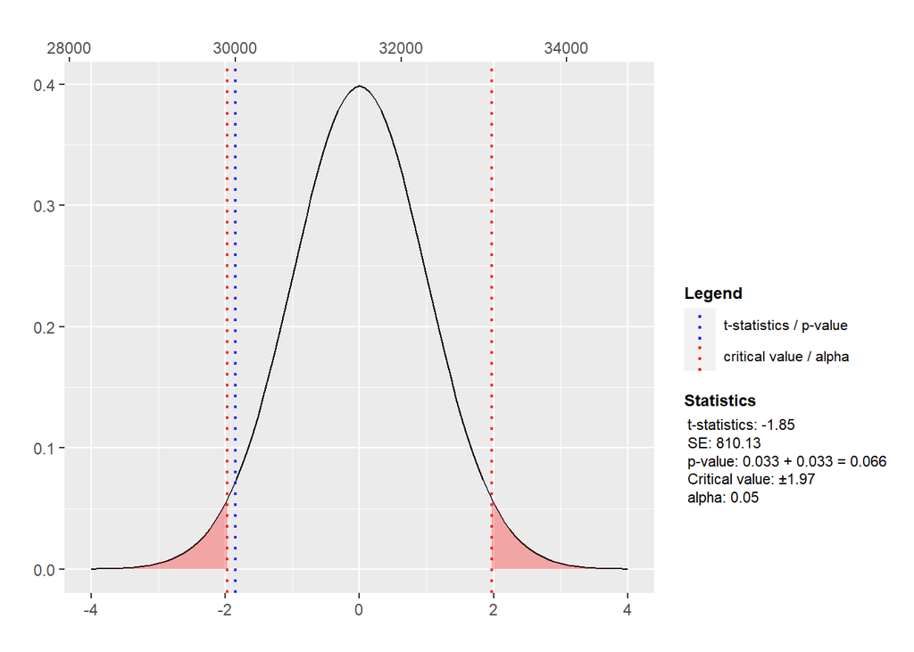

```r
plot_t_distribution(df_ipeds_sample$coa_grad_res, mu = 31500)
```

## 5.6 Rejection region and conclusion

### 5.6.1 Alpha level (rejection region)

$\alpha$ level (referred to as “alpha level” or “rejection region”)

- Definition: $\alpha$ level is a number such that we reject the null hypothesis $H_0$ the observed p-value is less than or equal to the alpha level.

In practice, the most common alpha level $\alpha$ is `.05`

- e.g., if we choose $\alpha= .05$ and our t-statistic is associated with a p-value of .02, then we reject $H_0$; if we choose $\alpha= .05$ and our t-statistic is associated with a p-value of .07, then we do not reject $H_0$
- sometimes researchers choose an alpha level of `.10` but usually this is viewed as not sufficiently strong threshold to reject $H_0$

Usually, you define alpha level **prior** to running analyses

- when researchers define alpha level (rejection region) *after* running analyses, there may be a temptation to choose an alpha level that allows them to reject $H_0$

To show how alpha level is used in practice, we’ll test the null hypothesis that population mean grad resident cost of attendance is `28,500`, initially using an alpha level of .05

- $H_0: \mu_Y = \mu_{Y0} = \$28,500$ and $H_a: \mu_Y \ne \$28,500$
- Sample mean, $\bar{Y} =$ 30002.745
- $t =$ 1.85
- p-value $= Pr(obs > t) + Pr(obs< -t) =$ 0.065
  - $Pr(obs>t)=$ 0.0325
  - $Pr(obs<-t)=$ 0.0325

Note that the `t.test()` function doesn’t have an argument that let’s you specify the alpha level (rejection region); rather, the idea is that you choose the alpha level and then compare that to the p-value calculated by `t.test()`

```r
t.test(x = df_ipeds_sample$coa_grad_res, mu = 28500)
```

```
#>
#>  One Sample t-test
#>
#> data:  df_ipeds_sample$coa_grad_res
#> t = 1.8549, df = 199, p-value = 0.06508
#> alternative hypothesis: true mean is not equal to 28500
#> 95 percent confidence interval:
#>  28405.20 31600.29
#> sample estimates:
#> mean of x
#>  30002.74
```

Note that the user-defined `plot_t_distribution()` includes an optional argument that allows you to specify the alpha-level

- syntax (including default argument values for arguments with defaults)
  - `plot_t_distribution(data_vec, mu, alpha = 0.05, alternative = 'two.sided', plot_title = '')`
  - So we can set the alpha level with the argument `alpha`, which has the default value of `0.05`

Below, we run `plot_t_distribution()`, manually setting the `alpha` argument to the the default value of `0.05`

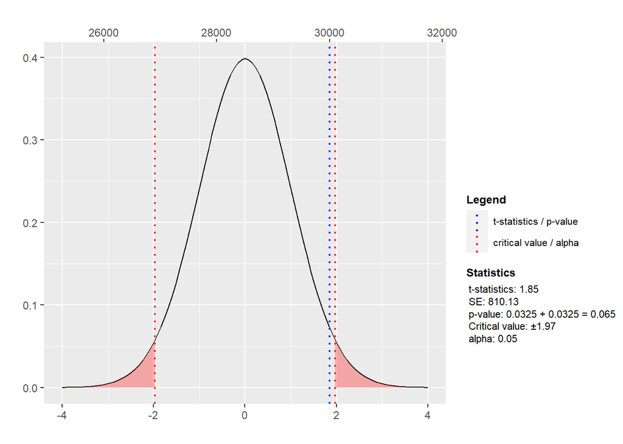

```r
plot_t_distribution(df_ipeds_sample$coa_grad_res, mu = 28500, alpha = .05)
```

How would our conclusion change if we chose an alpha level of .10?

- $H_0: \mu_Y = \mu_{Y0} = \$28,500$ and $H_a: \mu_Y \ne \$28,500$
- Sample mean, $\bar{Y} =$ 30002.745
- $t =$ 1.85
- p-value $= Pr(obs > t) + Pr(obs< -t) =$ 0.065
  - $Pr(obs>t)=$ 0.0325
  - $Pr(obs<-t)=$ 0.0325
- Since our p-value of 0.065 is less than the alpha level of .10, we reject $H_0$

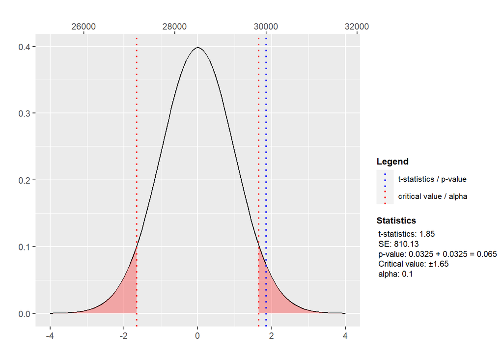

```r
plot_t_distribution(df_ipeds_sample$coa_grad_res, mu = 28500, alpha = .10)
```

### 5.6.2 Conclusion

Last step is to make a conclusion about your hypothesis based on comparing the p-value you observed to the alpha level

**How to state the conclusion**

- if p-value is greater than the alpha level $\alpha$ (e.g., $p-val =.06, \alpha = .05$)
  - conclusion: do not reject $H_0$
  - longer version: “We do not have sufficient evidence to reject the null hypothesis, $H_0$, that population mean $\mu_Y$ is equal to $\mu_{Y0}$”
  - do not say "we accept $H_0$ because we don’t know the exact value of the population parameter
- if p-value is less than the alpha level $\alpha$ (e.g., $p-val =.04, \alpha = .05$)
  - conclusion: we reject $H_0$
    - can also say “we accept $H_a$, but people usually say”reject $H_0$
  - longer version: “we reject the null hypothesis $H_0$, that population mean $\mu_Y$ is equal to $\mu_{Y0}$”

This example:

- $H_0: \mu_Y = \mu_{Y0} = \$28,500$ and $H_a: \mu_Y \ne \$28,500$ and alpha level $\alpha = .05$
- p-value $= Pr(obs > t) + Pr(obs< -t) =$ 0.065
- conclusion:
  - do not reject $H_0$
  - We do not have sufficient evidence to reject the null hypothesis, $H_0$, that population mean full-time resident graduate cost of attendance is equal to `28,500`

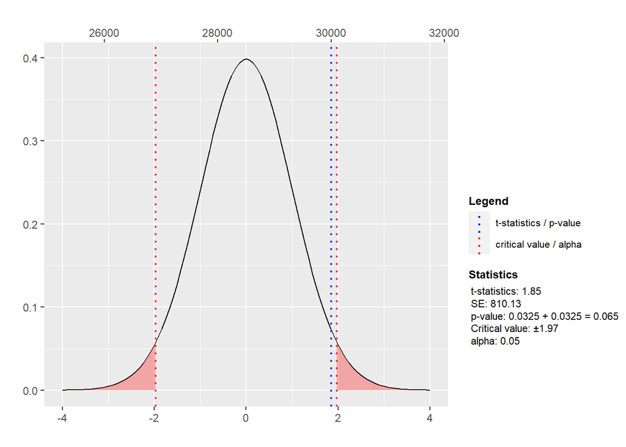

```r
plot_t_distribution(df_ipeds_sample$coa_grad_res, mu = 28500, alpha = .05,
                    shade_rejection = TRUE, shade_pval = FALSE)
```

## 5.7 Assumptions

All statistical tests (based on some statistical analysis) depends on “assumptions”

- *if* the researcher is confident that the assumptions have been satisfied, then the researcher can make inferences about the population parameter by applying the relevant statistical analysis/test to sample data
- if we are concerned that one or more assumptions have not been satisfied, then the researcher should not make inferences about the population parameter

Assumptions necessary for testing hypotheses about a population mean

1. sample is a random sample from population
2. population distribution of variable is normal

“Robust”

- A statistical method is robust with respect to a particular assumption, when it performs adequately even when that assumption is violated

Hyptohesis tests about a population mean is “robust” to the normal distribution assumption

- Statisticians have shown that hypothesis tests about population means are robust against violations of normal population assumption, especially when sample size > 30
- Why is hypothesis test about population means robust to normal population assumption? Because of central limit theorem

Central limit theorem:

- when sample size is large, the sampling distribution of the sample mean, 𝑦 , is approximately normal, even if the population distribution of the variable is not normal
- If population distribution is normal then sampling distribution is normal for any sample size
- If population distribution is not normal, sample size of about 30 is sufficient

Hypothesis test about population means is not robust to violations of random sampling

- i.e., if you take a non-random sample from the population, you cannot make good predictions about the population

## 5.8 Hypothesis test example, all steps

Research question:

- What is the population mean price of full-time nonresident graduate tuition + fees? [variable = `tuitfee_grad_nres`]

Let’s imagine we want to test whether the population mean, $\mu_Y = \$17,000$, using a two-sided alternative hypothesis and an alpha level of .05

State null and alternative hypotheses

- Null hypothesis, $H_0$
  - $H_0: \mu_Y = \mu_{Y0} = \$17,000$
  - $H_0:$ population mean price of full-time nonresident graduate tuition + fees is $17,000
- Alternative hypothesis, $H_a$
  - $H_0: \mu_Y \ne \$17,000$

Test statistic and p-value

Components of t-test

- sample size, $n$ = 200
- sample mean, $\bar{Y}$ = 18616.63
- Population mean associated with $H_0$, $\mu_{Y0} = \$17,000$
- sample standard deviation, $\hat{\sigma}_{Y}$ = 9976.3157
- sample standard error of the sample mean, $\hat{\sigma}_{\bar{Y}}$ = 705.432

Calculating t-test p-value using `t.test()`

- $t =$ 2.29
- p-value $= Pr(obs > t) + Pr(obs< -t) =$ 0.023
  - $Pr(obs>t)=$ 0.0115
  - $Pr(obs<-t)=$ 0.0115
- below code chunk runs t-test and plots t-value against sampling distribution assuming $H_0$ is true, using alpha of .05

```r
t.test(df_ipeds_sample$tuitfee_grad_nres, mu = 17000)
```

```
#>
#>  One Sample t-test
#>
#> data:  df_ipeds_sample$tuitfee_grad_nres
#> t = 2.2917, df = 199, p-value = 0.02297
#> alternative hypothesis: true mean is not equal to 17000
#> 95 percent confidence interval:
#>  17225.55 20007.71
#> sample estimates:
#> mean of x
#>  18616.63
```

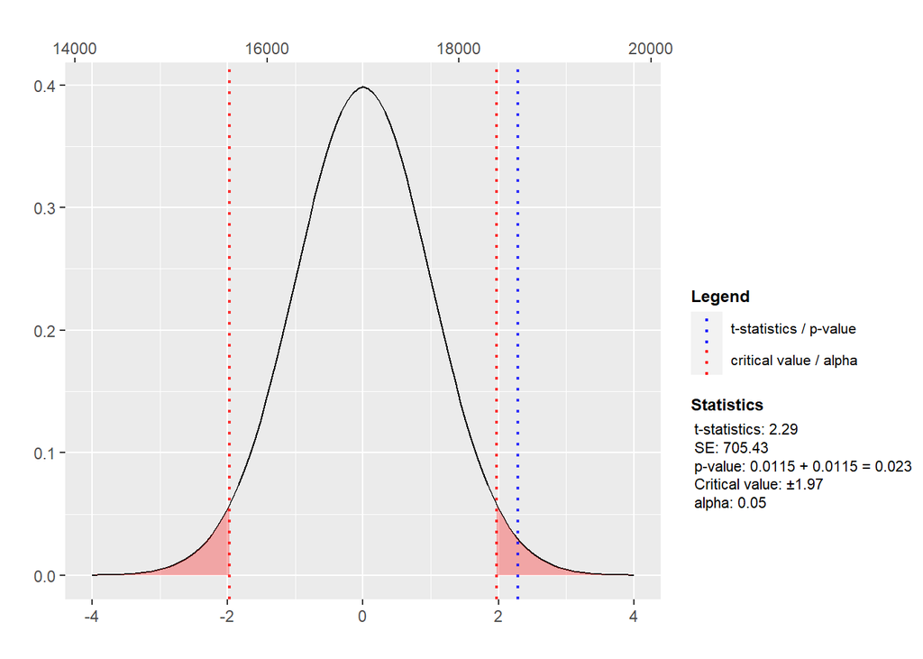

```r
plot_t_distribution(df_ipeds_sample$tuitfee_grad_nres, mu = 17000, alpha = .05,
  shade_rejection = TRUE, shade_pval = FALSE)
```

**Conclusion**

- Because the p-value of 0.023 is less than the alpha level of `.05`, we reject $H_0$
- we reject the null hypothesis $H_0$, population mean price of full-time nonresident graduate tuition + fees, $\mu_Y$, is equal to $17,000$
- We can also say that $\mu_Y$ is greater than $17,000$

Finally, we usually don’t have all data on the population. But since we do for IPEDS, we can plot:

- the population distribution (usually unknown)
- on top of the distribution from our single random sample
- on top of the sampling distribution (usually unknown)
- on top of the sampling distribution assuming $H_0$ is true

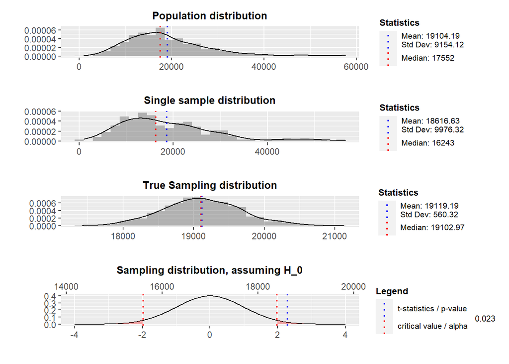

```r
plot_distribution(df_ipeds_pop$tuitfee_grad_nres, plot_title = 'Population distribution') +
  plot_distribution(df_ipeds_sample$tuitfee_grad_nres, plot_title = 'Single sample distribution') +
  plot_distribution(get_sampling_distribution(df_ipeds_pop$tuitfee_grad_nres), plot_title = 'True Sampling distribution') +
  plot_t_distribution(df_ipeds_sample$tuitfee_grad_nres, mu = 17000, plot_title = 'Sampling distribution, assuming H_0') +
  plot_layout(ncol = 1)
```

# 6 Fundamentals of causal inference

# 7 Hypothesis testing about two populations

# References

Cabrera, N. L., Milem, J. F., Jaquette, O., & Marx, R. (2014). Missing the (student achievement) forest for all the (political) trees: Empiricism and the mexican american studies controversy in tucson. *American Educational Research Journal*, *51*(6), 1084–1118.

Curs, B. R., & Jaquette, O. (2017). Crowded out? The effect of nonresident enrollment on resident access to public research universities. *Educational Evaluation and Policy Analysis*, *39*(4), 644–669. https://doi.org/10.3102/0162373717704719

Jaquette, O., & Curs, B. R. (2015). Creating the out-of-state university: Do public universities increase nonresident freshman enrollment in response to declining state appropriations? *Research in Higher Education*, *56*(6), 535–565. https://doi.org/10.1007/s11162-015-9362-2

Salazar, K., Jaquette, O., & Han, C. (n.d.). Coming soon to a neighborhood near you? Off-campus recruiting by public research universities. *American Educational Research Journal*.